# **Contents**

# **Importing Libraries and Packages**

We will use these packages to help us manipulate the data and visualize the features/labels as well as measure how well our model performed. Numpy and Pandas are helpful for manipulating the dataframe and its columns and cells. We will use matplotlib along with Seaborn to visualize our data.

```python
import numpy as np
import pandas as pd

import seaborn as sns
from matplotlib import pyplot as plt
import missingno as msno  #missing data
from dtreeviz.trees import *  #decision tree visualization
from IPython.display import Image, display_svg
sns.set_style("whitegrid")
%matplotlib inline

from dtreeviz.trees import *
from IPython.display import Image, display_svg

from sklearn.impute import SimpleImputer
from sklearn.preprocessing import OneHotEncoder

import os
from sklearn.preprocessing import StandardScaler
from sklearn.svm import SVC, LinearSVC
from sklearn.ensemble import RandomForestClassifier
from sklearn.linear_model import LogisticRegression
from sklearn.neighbors import KNeighborsClassifier
from sklearn.naive_bayes import GaussianNB
from sklearn.tree import DecisionTreeClassifier

from sklearn.model_selection import train_test_split
from sklearn.metrics import make_scorer, accuracy_score
from sklearn.model_selection import GridSearchCV


import warnings
warnings.filterwarnings("ignore")
#print(os.listdir("../input"))
```

# **Loading and Viewing Data Set**

```python
# Print options
np.set_printoptions(precision=4, threshold=10000, linewidth=160, edgeitems=999, suppress=True)
pd.set_option('display.max_columns', None)
pd.set_option('display.max_rows', None)
pd.set_option('display.width', 160)
pd.set_option('expand_frame_repr', False)
pd.set_option('precision', 4)
""" fix flow to 3 places"""
pd.options.display.float_format = '{:,.2f}'.format
```

```python
print(os.listdir("/Volumes/GoogleDrive/My Drive/data/cvdata"))
```

```
['oppty_sampling_jun15.csv', 'oppty_sampling_jun25.sql', 'getting_data.ipynb', 'feature_engineering (june19).ipynb', 'oppty_sampling_jun25 .csv', 'oppty_sampling_jun26.csv', 'tiny_pipe_test.ipynb', 'data_tiny', 'Icon\r']
```

```python
datadirectory = "/Volumes/GoogleDrive/My Drive/data/cvdata/"
```

```python
data = pd.read_csv(datadirectory+"oppty_sampling_jun26.csv",low_memory=False )
data.head()
```

|  | Unnamed: 0 | opp_id | opp_createddate | inflowdate__c | closedate | stagename | accountid | software_amount__c | no_software_amount__c | acquisitiontype__c | additionalinformation__c | addressablepainproject__c | amountofprimarydatainenvironment__c | whycommvault__c | neworexistingcustomer__c | creatorrole__c | dealledby__c | mql__c | se_notes__c | visibilityofproblem__c | timing__c | need__c | salesprocess__c | partnervalueadd__c | sdnote__c | new_project_or_add_on_revenue__c | number_of_servers_for_this_opportunity__c | opportunitydescriptioncomments__c | relationshiptype_text__c | … |
| --- | --- | --- | --- | --- | --- | --- | --- | --- | --- | --- | --- | --- | --- | --- | --- | --- | --- | --- | --- | --- | --- | --- | --- | --- | --- | --- | --- | --- | --- | --- |
| 0 | 0 | 0061W00000rQTdAQAW | 2017-09-18 05:25:27.0000000 | 2017-09-19 00:00:00.0000000 | 2017-09-25 00:00:00.0000000 | Closed/Won | 0011W00001qosMLQAY | 1,900.49 | 0.00 | Perpetual | NaN | Backup | NaN | NaN | New | NaN | CVLT | 1.00 | NaN | NaN | 4-6 Months | Backup | Extended | NaN | NaN | NaN | NaN | NaN | End User - Former Customer | … |
| 1 | 1 | 0061W00000rQg1WQAS | 2017-09-19 15:34:33.0000000 | 2017-09-20 00:00:00.0000000 | 2018-02-04 00:00:00.0000000 | Closed / Lost | 0011W00001qpE9iQAE | 15,000.00 | 0.00 | Perpetual | NaN | NaN | NaN | NaN | New | Sales and Partner Administrator | Partner | 0.00 | NaN | NaN | NaN | NaN | Extended | NaN | Qualifying | New Project | NaN | Customer is running Proxmox (Opensource versio... | End User - Prospect | … |
| 2 | 2 | 0061W00000rQjwnQAC | 2017-09-20 06:43:09.0000000 | 2017-09-20 00:00:00.0000000 | 2018-11-26 00:00:00.0000000 | Closed / Lost | 0011W00001qpJdGQAU | 10,000.00 | 0.00 | Perpetual | NaN | NaN | NaN | NaN | New | Territory Account Manager | CVLT | nan | NaN | NaN | NaN | NaN | Extended | NaN | no news | New Project | NaN | NaN | End User - Prospect | … |
| 3 | 3 | 0061W00000rQpUAQA0 | 2017-09-20 23:05:43.0000000 | 2017-09-29 00:00:00.0000000 | 2017-12-14 00:00:00.0000000 | Closed/Won | 0011W00001qpJk2QAE | 3,162.95 | 0.00 | Perpetual | "项目为藏文化数字化工程技术研究中心软、硬件购置项目： 2个AIX数据库备份许可（不限数据库... | Backup Solution | NaN | NaN | New | NaN | Partner | 1.00 | NaN | Director | 7-12 Months | Backup Solution | Extended | NaN | NaN | NaN | NaN | NaN | End User - Former Customer | … |
| 4 | 4 | 0061W00000rQl9oQAC | 2017-09-20 10:43:02.0000000 | 2017-09-20 00:00:00.0000000 | 2018-01-25 00:00:00.0000000 | Closed / Lost | 0011W00001qpKw7QAE | 14,000.00 | 0.00 | Perpetual | NaN | NaN | NaN | NaN | New | Sales and Partner Administrator | Partner | 0.00 | NaN | NaN | NaN | NaN | Extended | NaN | Qualifying | New Project | NaN | El cliente desea revisar el backup de su organ... | End User - Prospect | … |

```python
#remove column
del data['Unnamed: 0']
data.head(1)
```

|  | opp_id | opp_createddate | inflowdate__c | closedate | stagename | accountid | software_amount__c | no_software_amount__c | acquisitiontype__c | additionalinformation__c | addressablepainproject__c | amountofprimarydatainenvironment__c | whycommvault__c | neworexistingcustomer__c | creatorrole__c | dealledby__c | mql__c | se_notes__c | visibilityofproblem__c | timing__c | need__c | salesprocess__c | partnervalueadd__c | sdnote__c | new_project_or_add_on_revenue__c | number_of_servers_for_this_opportunity__c | opportunitydescriptioncomments__c | relationshiptype_text__c | reportinglevel0__c | … |
| --- | --- | --- | --- | --- | --- | --- | --- | --- | --- | --- | --- | --- | --- | --- | --- | --- | --- | --- | --- | --- | --- | --- | --- | --- | --- | --- | --- | --- | --- | --- |
| 0 | 0061W00000rQTdAQAW | 2017-09-18 05:25:27.0000000 | 2017-09-19 00:00:00.0000000 | 2017-09-25 00:00:00.0000000 | Closed/Won | 0011W00001qosMLQAY | 1,900.49 | 0.00 | Perpetual | NaN | Backup | NaN | NaN | New | NaN | CVLT | 1.00 | NaN | NaN | 4-6 Months | Backup | Extended | NaN | NaN | NaN | NaN | NaN | End User - Former Customer | APAC | … |

## pandas type converstions:

dates to pandas datetime formats

```python
data['opp_createddate'] = pd.to_datetime(data['opp_createddate'], errors='coerce') #replaces errors with NAT
data['inflowdate__c'] = pd.to_datetime(data['inflowdate__c'], errors='coerce') #replaces errors with NAT
data['closedate'] = pd.to_datetime(data['closedate'], errors='coerce') #replaces errors with NAT
data['firstwindate'] = pd.to_datetime(data['firstwindate'], errors='coerce') #replaces errors with NAT
```

```python
print("Total size of all sample from sql db", data.shape)
```

```
Total size of all sample from sql db (72401, 54)
```

# **Split data between _Prospect versus _Existing Customer**

> Prospect is calculated as 'fireswindate' is null or 'closedate' = 'firstwinddate' opporunity

```python
# capture first win dates that match close date
data['is_firstwindate'] = (data.firstwindate==data.closedate).astype(int)
print("new customer wins,\n firstwindate = closedate", data['is_firstwindate'].sum())
```

```
new customer wins,
 firstwindate = closedate 6331
```

```python
data['no_firstwindate'] = data.firstwindate.isnull().astype(int)
print("additional prospects,\n total with null as firstwindate \n", data.firstwindate.isnull().sum())
```

```
additional prospects,
 total with null as firstwindate
 25655
```

```python
# create new column for prospect versus existing customer
data['cust_model'] = ((data['no_firstwindate'] + data['is_firstwindate']) > 0).astype(int)
print("total opporunities where new firstwindate is missing or closedate matches firstwindate\n",data['cust_model'].sum())
```

```
total opporunities where new firstwindate is missing or closedate matches firstwindate
 31986
```

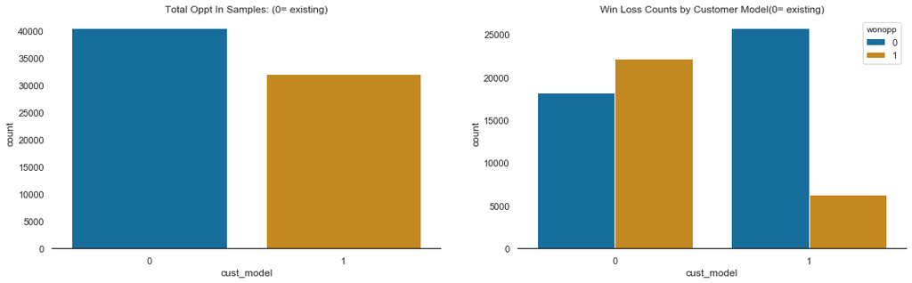

```python
#Specify figure size
sns.set(style='white', palette='colorblind')
fig, axes = plt.subplots(1, 2, figsize=(18, 5), sharey=False)
sns.despine(left=True)

sns.countplot(x="cust_model", data=data, ax=axes[0])
axes[0].set_title('Total Oppt In Samples: (0= existing)')
sns.countplot(x="cust_model", hue="wonopp", data=data, ax=axes[1])
axes[1].set_title('Win Loss Counts by Customer Model(0= existing)', fontsize=12);
```

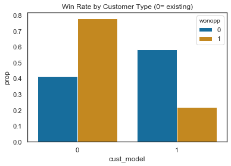

```python
x, y, hue = "cust_model","prop", "wonopp",
hue_order = [0, 1]
prop_df = (data[x]
           .groupby(data[hue])
           .value_counts(normalize=True)
           .rename(y)
           .reset_index())
#axes.set_title('Total Oppt In Samples: (0= existing)')
sns.barplot(x=x, y=y, hue=hue, data=prop_df).set_title("Win Rate by Customer Type (0= existing)");
```

```python
# props = data.groupby("cust_model")['wonopp'].value_counts(normalize=True).unstack()
# props.plot(kind='bar',
#            stacked='True',
#            table=False,
#            title="Base Win Rate for Sample",
#            figsize=(10, 5));
```

# **Create New Customer Model Datasets:**

> New_Customer Model dataframes from 31,986 prospects.
> 1. Training and Test 2/3 = 21,324
> 2. Holdout 1/3 = 10,662

```python
is_prospect =  data['cust_model']==1
data_new = data[is_prospect].copy()
print("Size of New Customer Sample", data_new.shape)
```

```
Size of New Customer Sample (31986, 57)
```

```python
# create new column with random numbered column 1 to 31,986.
number_in_sample = len(data_new)
sample_no = np.random.choice(number_in_sample, size=(1,number_in_sample), replace=False)+1
data_new['sample_num'] = sample_no[0]
print("min number sample num= ",
      data_new['sample_num'].min(),
     "\n max number in sample =",
     data_new['sample_num'].max())
```

```
min number sample num=  1
 max number in sample = 31986
```

```python
is_training =  data_new['sample_num']<=21324
new_train = data_new[is_training].copy()
print("Size Training Sample", new_train.shape)
```

```
Size Training Sample (21324, 58)
```

```python
# create list of columns to remove based on not useful, remove from sql query
new_train.sample(5)
```

|  | opp_id | opp_createddate | inflowdate__c | closedate | stagename | accountid | software_amount__c | no_software_amount__c | acquisitiontype__c | additionalinformation__c | addressablepainproject__c | amountofprimarydatainenvironment__c | whycommvault__c | neworexistingcustomer__c | creatorrole__c | dealledby__c | mql__c | se_notes__c | visibilityofproblem__c | timing__c | need__c | salesprocess__c | partnervalueadd__c | sdnote__c | new_project_or_add_on_revenue__c | number_of_servers_for_this_opportunity__c | opportunitydescriptioncomments__c | relationshiptype_text__c | reportinglevel0__c | … |
| --- | --- | --- | --- | --- | --- | --- | --- | --- | --- | --- | --- | --- | --- | --- | --- | --- | --- | --- | --- | --- | --- | --- | --- | --- | --- | --- | --- | --- | --- | --- |
| 62639 | 0064000000pPwBDAA0 | 2017-06-16 09:13:08 | 2017-06-19 | 2017-06-28 | Closed/Won | 0014000001m7BKyAAM | 7,881.65 | 0.00 | Perpetual | NaN | NaN | NaN | NaN | Existing | Inside Sales Administrator | Partner & CVLT | 0.00 | NaN | NaN | NaN | NaN | Quick | NaN | NaN | NaN | NaN | Software-Defined Data Center Project | End User - Customer | APAC | … |
| 57606 | 0064000000k3gvQAAQ | 2016-07-03 19:01:18 | 2016-07-03 | 2017-03-29 | Closed/Won | 0014000001iTKJrAAO | 17,124.75 | 0.00 | Perpetual | NaN | NaN | NaN | NaN | New | Inside Sales Administrator | CVLT | 0.00 | NaN | NaN | NaN | NaN | Extended | NaN | NaN | NaN | NaN | NaN | End User - Customer | APAC | … |
| 25841 | 0064000000iY2RbAAK | 2016-03-18 13:34:22 | 2016-03-18 | 2016-04-29 | Closed / Lost | 0014000000iEtbVAAS | 5,260.08 | 0.00 | Perpetual | NaN | NaN | NaN | NaN | Existing | Inside Sales Representative | CVLT | nan | NaN | NaN | NaN | NaN | Quick | NaN | NaN | New Project | NaN | NaN | End User - Former Customer | Americas | … |
| 25683 | 0064000000naSNrAAM | 2017-03-03 14:11:07 | 2017-03-03 | 2018-03-15 | Closed / Lost | 0014000000IDIhmAAH | 40,000.00 | 0.00 | Perpetual | NaN | NaN | NaN | NaN | New | Enterprise Account Executive | CVLT | nan | NaN | NaN | NaN | NaN | Extended | NaN | Qualifying with ACS | New Project | NaN | NaN | End User - Prospect | Americas | … |
| 2057 | 0061W00000y1FDrQAM | 2018-03-26 03:19:58 | 2018-03-28 | 2018-03-28 | Closed/Won | 0011W00001t5J5vQAE | 1,644.27 | 0.00 | Perpetual | NaN | NaN | NaN | NaN | New | Partner Business Manager | NaN | nan | NaN | NaN | NaN | NaN | Quick | NaN | NaN | New Project | NaN | NaN | End User - Customer | EMEA | … |

```python
#confrim if there are any previous wins marked in opportunties in new_train =
new_train.loc[new_train['wonsw24months']> 0]
```

|  | opp_id | opp_createddate | inflowdate__c | closedate | stagename | accountid | software_amount__c | no_software_amount__c | acquisitiontype__c | additionalinformation__c | addressablepainproject__c | amountofprimarydatainenvironment__c | whycommvault__c | neworexistingcustomer__c | creatorrole__c | dealledby__c | mql__c | se_notes__c | visibilityofproblem__c | timing__c | need__c | salesprocess__c | partnervalueadd__c | sdnote__c | new_project_or_add_on_revenue__c | number_of_servers_for_this_opportunity__c | opportunitydescriptioncomments__c | relationshiptype_text__c | reportinglevel0__c | … |
| --- | --- | --- | --- | --- | --- | --- | --- | --- | --- | --- | --- | --- | --- | --- | --- | --- | --- | --- | --- | --- | --- | --- | --- | --- | --- | --- | --- | --- | --- | --- |

```python
#confrim if there are any previous wins marked in opportunties in new_train =
new_train.loc[new_train['wonsw12months']> 0]
```

|  | opp_id | opp_createddate | inflowdate__c | closedate | stagename | accountid | software_amount__c | no_software_amount__c | acquisitiontype__c | additionalinformation__c | addressablepainproject__c | amountofprimarydatainenvironment__c | whycommvault__c | neworexistingcustomer__c | creatorrole__c | dealledby__c | mql__c | se_notes__c | visibilityofproblem__c | timing__c | need__c | salesprocess__c | partnervalueadd__c | sdnote__c | new_project_or_add_on_revenue__c | number_of_servers_for_this_opportunity__c | opportunitydescriptioncomments__c | relationshiptype_text__c | reportinglevel0__c | … |
| --- | --- | --- | --- | --- | --- | --- | --- | --- | --- | --- | --- | --- | --- | --- | --- | --- | --- | --- | --- | --- | --- | --- | --- | --- | --- | --- | --- | --- | --- | --- |

```python
#confrim if there are any previous wins marked in opportunties in new_train =
new_train.loc[new_train['wonopps12months']> 0]
```

```python
#confrim if there are any previous wins marked in opportunties in new_train =
new_train.loc[new_train['wonsw12months']> 0]
```

```python
columsToRemove = ['wonopp','no_software_amount__c' ,'neworexistingcustomer__c',
                  'wonsw24months','lostsw24months','wonsw12months'
                  ,'lostsw12months','wonopps24months','lostopps24months'
                  ,'wonopps12months','lostopps12months','openopps'
                  ,'opensw','is_firstwindate','no_firstwindate'
                  ,'cust_model','sample_num']
```

```python
# move the winopp target column to be the first
print("""reorder columns so that target variable is in postion 0 for columns""")
data_columns = list(new_train.columns.values)
for column in columsToRemove:
    data_columns.remove(column)
new_col_list = list(['wonopp'])
new_col_list.extend(data_columns)
new_train = new_train.reindex(columns=new_col_list)
new_train.head()
```

```
reorder columns so that target variable is in postion 0 for columns
```

|  | wonopp | opp_id | opp_createddate | inflowdate__c | closedate | stagename | accountid | software_amount__c | acquisitiontype__c | additionalinformation__c | addressablepainproject__c | amountofprimarydatainenvironment__c | whycommvault__c | creatorrole__c | dealledby__c | mql__c | se_notes__c | visibilityofproblem__c | timing__c | need__c | salesprocess__c | partnervalueadd__c | sdnote__c | new_project_or_add_on_revenue__c | number_of_servers_for_this_opportunity__c | opportunitydescriptioncomments__c | relationshiptype_text__c | reportinglevel0__c | reportinglevel1__c | … |
| --- | --- | --- | --- | --- | --- | --- | --- | --- | --- | --- | --- | --- | --- | --- | --- | --- | --- | --- | --- | --- | --- | --- | --- | --- | --- | --- | --- | --- | --- | --- |
| 2 | 0 | 0061W00000rQjwnQAC | 2017-09-20 06:43:09 | 2017-09-20 | 2018-11-26 | Closed / Lost | 0011W00001qpJdGQAU | 10,000.00 | Perpetual | NaN | NaN | NaN | NaN | Territory Account Manager | CVLT | nan | NaN | NaN | NaN | NaN | Extended | NaN | no news | New Project | NaN | NaN | End User - Prospect | EMEA | Territory | … |
| 4 | 0 | 0061W00000rQl9oQAC | 2017-09-20 10:43:02 | 2017-09-20 | 2018-01-25 | Closed / Lost | 0011W00001qpKw7QAE | 14,000.00 | Perpetual | NaN | NaN | NaN | NaN | Sales and Partner Administrator | Partner | 0.00 | NaN | NaN | NaN | NaN | Extended | NaN | Qualifying | New Project | NaN | El cliente desea revisar el backup de su organ... | End User - Prospect | Americas | US West & LATAM | … |
| 7 | 1 | 0061W00000ogYAMQA2 | 2017-09-26 11:10:54 | 2017-09-26 | 2017-10-04 | Closed/Won | 0011W00001r5K2rQAE | 23,368.00 | Perpetual | NaN | NaN | NaN | NaN | Territory Account Manager | Partner | nan | NaN | NaN | NaN | NaN | Extended | NaN | Peter Dresbach is looking internal for PO\nFuj... | New Project | NaN | NaN | End User - Customer | EMEA | Territory | … |
| 10 | 1 | 0061W00000ogfrRQAQ | 2017-09-27 09:22:37 | 2017-09-27 | 2017-12-25 | Closed/Won | 0011W00001r5X4BQAU | 17,965.66 | Perpetual | NaN | NaN | NaN | NaN | Inside Sales Representative | Partner & CVLT | nan | NaN | NaN | NaN | NaN | Extended | NaN | PO received Commvault APAC | New Project | NaN | NaN | End User - Customer | EMEA | Large National | … |
| 11 | 0 | 0061W00000ogWmjQAE | 2017-09-26 08:45:23 | 2017-09-28 | 2017-10-26 | Closed / Lost | 0011W00001qosIdQAI | 3,000.00 | Perpetual | Background\n10 - 15 TB\non premise data being ... | GDPR Compliance and migration to the cloud | 11-15 TB | NaN | NaN | CVLT | 1.00 | NaN | Director | 4-6 Months | GDPR\nMigration to the cloud\nArchiving and in... | Extended | NaN | NaN | NaN | NaN | NaN | End User - Prospect | EMEA | Territory | … |

# **Create Recency Variables by Prospect**

this needs to be adjusted to account for oppty happening before measurement period to account for recency in last oppty

from Opporuntity Data

```python
#recency dataframe
tx_day_order = new_train[['accountid','inflowdate__c', 'closedate', 'opp_id', 'software_amount__c', 'wonopp']]
tx_day_order.head()
```

|  | accountid | inflowdate__c | closedate | opp_id | software_amount__c | wonopp |
| --- | --- | --- | --- | --- | --- | --- |
| 2 | 0011W00001qpJdGQAU | 2017-09-20 | 2018-11-26 | 0061W00000rQjwnQAC | 10,000.00 | 0 |
| 4 | 0011W00001qpKw7QAE | 2017-09-20 | 2018-01-25 | 0061W00000rQl9oQAC | 14,000.00 | 0 |
| 7 | 0011W00001r5K2rQAE | 2017-09-26 | 2017-10-04 | 0061W00000ogYAMQA2 | 23,368.00 | 1 |
| 10 | 0011W00001r5X4BQAU | 2017-09-27 | 2017-12-25 | 0061W00000ogfrRQAQ | 17,965.66 | 1 |
| 11 | 0011W00001qosIdQAI | 2017-09-28 | 2017-10-26 | 0061W00000ogWmjQAE | 3,000.00 | 0 |

```python
#convert Invoice Datetime to day
tx_day_order['closedate'] = tx_day_order['closedate'].dt.date
tx_day_order = tx_day_order.sort_values(['accountid','closedate'])
```

```python
#tx_day_order.sample(10)
```

```python
# shift by accountid for get previous close day
tx_day_order['PrevCloseDate'] = tx_day_order.groupby(['accountid'])['closedate'].shift(1)
#tx_day_order.sample(3)
```

```python
#track account with previous opps
tx_day_order.loc[tx_day_order['accountid']== '0014000000eVZ0MAAW'].sort_values(by=['closedate'],ascending=True)
```

|  | accountid | inflowdate__c | closedate | opp_id | software_amount__c | wonopp | PrevCloseDate |
| --- | --- | --- | --- | --- | --- | --- | --- |
| 4181 | 0014000000eVZ0MAAW | 2015-06-23 | 2016-09-27 | 0064000000fDfooAAC | 20,000.00 | 0 | NaN |
| 14816 | 0014000000eVZ0MAAW | 2018-01-16 | 2018-05-15 | 0061W00000uFeljQAC | 5,238.14 | 0 | 2016-09-27 |
| 8908 | 0014000000eVZ0MAAW | 2017-08-16 | 2018-05-17 | 0064000000qtkaMAAQ | 37,542.95 | 0 | 2018-05-15 |
| 4180 | 0014000000eVZ0MAAW | 2018-07-31 | 2019-02-11 | 0061W000011S0udQAC | 3,822.53 | 0 | 2018-05-17 |

```python
#add column for count of days from previous close
tx_day_order['dayfromlastddayclose'] = (tx_day_order['closedate']-tx_day_order['PrevCloseDate'])/ np.timedelta64(1, 'D')
```

```python
#track account with previous opps
tx_day_order.loc[tx_day_order['accountid']== '0014000000eVZ0MAAW'].sort_values(by=['closedate'],ascending=True)
```

|  | accountid | inflowdate__c | closedate | opp_id | software_amount__c | wonopp | PrevCloseDate | dayfromlastddayclose |
| --- | --- | --- | --- | --- | --- | --- | --- | --- |
| 4181 | 0014000000eVZ0MAAW | 2015-06-23 | 2016-09-27 | 0064000000fDfooAAC | 20,000.00 | 0 | NaN | nan |
| 14816 | 0014000000eVZ0MAAW | 2018-01-16 | 2018-05-15 | 0061W00000uFeljQAC | 5,238.14 | 0 | 2016-09-27 | 595.00 |
| 8908 | 0014000000eVZ0MAAW | 2017-08-16 | 2018-05-17 | 0064000000qtkaMAAQ | 37,542.95 | 0 | 2018-05-15 | 2.00 |
| 4180 | 0014000000eVZ0MAAW | 2018-07-31 | 2019-02-11 | 0061W000011S0udQAC | 3,822.53 | 0 | 2018-05-17 | 270.00 |

```python
#count of previus closes happening in last 365 days
tx_day_order['has_prev_close'] = (tx_day_order['dayfromlastddayclose'] < 365).astype(int)
#track account with previous opps
tx_day_order.loc[tx_day_order['accountid']== '0014000000eVZ0MAAW'].sort_values(by=['closedate'],ascending=True)
```

|  | accountid | inflowdate__c | closedate | opp_id | software_amount__c | wonopp | PrevCloseDate | dayfromlastddayclose | has_prev_close |
| --- | --- | --- | --- | --- | --- | --- | --- | --- | --- |
| 4181 | 0014000000eVZ0MAAW | 2015-06-23 | 2016-09-27 | 0064000000fDfooAAC | 20,000.00 | 0 | NaN | nan | 0 |
| 14816 | 0014000000eVZ0MAAW | 2018-01-16 | 2018-05-15 | 0061W00000uFeljQAC | 5,238.14 | 0 | 2016-09-27 | 595.00 | 0 |
| 8908 | 0014000000eVZ0MAAW | 2017-08-16 | 2018-05-17 | 0064000000qtkaMAAQ | 37,542.95 | 0 | 2018-05-15 | 2.00 | 1 |
| 4180 | 0014000000eVZ0MAAW | 2018-07-31 | 2019-02-11 | 0061W000011S0udQAC | 3,822.53 | 0 | 2018-05-17 | 270.00 | 1 |

```python
# cummulative previous closes
tx_day_order['cum_prev_close'] = tx_day_order.groupby('accountid')['has_prev_close'].transform(lambda g: g.cumsum()-g.iat[0])
tx_day_order.loc[tx_day_order['accountid']== '0014000000eVZ0MAAW'].sort_values(by=['closedate'],ascending=True)
```

|  | accountid | inflowdate__c | closedate | opp_id | software_amount__c | wonopp | PrevCloseDate | dayfromlastddayclose | has_prev_close | cum_prev_close |
| --- | --- | --- | --- | --- | --- | --- | --- | --- | --- | --- |
| 4181 | 0014000000eVZ0MAAW | 2015-06-23 | 2016-09-27 | 0064000000fDfooAAC | 20,000.00 | 0 | NaN | nan | 0 | 0 |
| 14816 | 0014000000eVZ0MAAW | 2018-01-16 | 2018-05-15 | 0061W00000uFeljQAC | 5,238.14 | 0 | 2016-09-27 | 595.00 | 0 | 0 |
| 8908 | 0014000000eVZ0MAAW | 2017-08-16 | 2018-05-17 | 0064000000qtkaMAAQ | 37,542.95 | 0 | 2018-05-15 | 2.00 | 1 | 1 |
| 4180 | 0014000000eVZ0MAAW | 2018-07-31 | 2019-02-11 | 0061W000011S0udQAC | 3,822.53 | 0 | 2018-05-17 | 270.00 | 1 | 2 |

```python
# shift by accountid for get previous close day
tx_day_order['PrevCloseAmt'] = tx_day_order.groupby(['accountid'])['software_amount__c'].shift(1)
tx_day_order.loc[tx_day_order['accountid']== '0014000000eVZ0MAAW'].sort_values(by=['closedate'],ascending=True)
```

|  | accountid | inflowdate__c | closedate | opp_id | software_amount__c | wonopp | PrevCloseDate | dayfromlastddayclose | has_prev_close | cum_prev_close | PrevCloseAmt |
| --- | --- | --- | --- | --- | --- | --- | --- | --- | --- | --- | --- |
| 4181 | 0014000000eVZ0MAAW | 2015-06-23 | 2016-09-27 | 0064000000fDfooAAC | 20,000.00 | 0 | NaN | nan | 0 | 0 | nan |
| 14816 | 0014000000eVZ0MAAW | 2018-01-16 | 2018-05-15 | 0061W00000uFeljQAC | 5,238.14 | 0 | 2016-09-27 | 595.00 | 0 | 0 | 20,000.00 |
| 8908 | 0014000000eVZ0MAAW | 2017-08-16 | 2018-05-17 | 0064000000qtkaMAAQ | 37,542.95 | 0 | 2018-05-15 | 2.00 | 1 | 1 | 5,238.14 |
| 4180 | 0014000000eVZ0MAAW | 2018-07-31 | 2019-02-11 | 0061W000011S0udQAC | 3,822.53 | 0 | 2018-05-17 | 270.00 | 1 | 2 | 37,542.95 |

```python
# create prevous close amounts
tx_day_order.loc[(tx_day_order['wonopp'] == 0)
                 & (tx_day_order['dayfromlastddayclose']< 365),
                 'PrevLostAmount' ] = tx_day_order['PrevCloseAmt']
tx_day_order.loc[tx_day_order['accountid']== '0014000000eVZ0MAAW'].sort_values(by=['closedate'],ascending=True)
```

|  | accountid | inflowdate__c | closedate | opp_id | software_amount__c | wonopp | PrevCloseDate | dayfromlastddayclose | has_prev_close | cum_prev_close | PrevCloseAmt | PrevLostAmount |
| --- | --- | --- | --- | --- | --- | --- | --- | --- | --- | --- | --- | --- |
| 4181 | 0014000000eVZ0MAAW | 2015-06-23 | 2016-09-27 | 0064000000fDfooAAC | 20,000.00 | 0 | NaN | nan | 0 | 0 | nan | nan |
| 14816 | 0014000000eVZ0MAAW | 2018-01-16 | 2018-05-15 | 0061W00000uFeljQAC | 5,238.14 | 0 | 2016-09-27 | 595.00 | 0 | 0 | 20,000.00 | nan |
| 8908 | 0014000000eVZ0MAAW | 2017-08-16 | 2018-05-17 | 0064000000qtkaMAAQ | 37,542.95 | 0 | 2018-05-15 | 2.00 | 1 | 1 | 5,238.14 | 5,238.14 |
| 4180 | 0014000000eVZ0MAAW | 2018-07-31 | 2019-02-11 | 0061W000011S0udQAC | 3,822.53 | 0 | 2018-05-17 | 270.00 | 1 | 2 | 37,542.95 | 37,542.95 |

```python
tx_day_order['CumLostAmount'] = tx_day_order.groupby('accountid')['PrevLostAmount'].cumsum()
tx_day_order.loc[tx_day_order['accountid']== '0014000000eVZ0MAAW'].sort_values(by=['closedate'],ascending=True)
```

|  | accountid | inflowdate__c | closedate | opp_id | software_amount__c | wonopp | PrevCloseDate | dayfromlastddayclose | has_prev_close | cum_prev_close | PrevCloseAmt | PrevLostAmount | CumLostAmount |
| --- | --- | --- | --- | --- | --- | --- | --- | --- | --- | --- | --- | --- | --- |
| 4181 | 0014000000eVZ0MAAW | 2015-06-23 | 2016-09-27 | 0064000000fDfooAAC | 20,000.00 | 0 | NaN | nan | 0 | 0 | nan | nan | nan |
| 14816 | 0014000000eVZ0MAAW | 2018-01-16 | 2018-05-15 | 0061W00000uFeljQAC | 5,238.14 | 0 | 2016-09-27 | 595.00 | 0 | 0 | 20,000.00 | nan | nan |
| 8908 | 0014000000eVZ0MAAW | 2017-08-16 | 2018-05-17 | 0064000000qtkaMAAQ | 37,542.95 | 0 | 2018-05-15 | 2.00 | 1 | 1 | 5,238.14 | 5,238.14 | 5,238.14 |
| 4180 | 0014000000eVZ0MAAW | 2018-07-31 | 2019-02-11 | 0061W000011S0udQAC | 3,822.53 | 0 | 2018-05-17 | 270.00 | 1 | 2 | 37,542.95 | 37,542.95 | 42,781.09 |

## Create OpportunityAge variable from inflow date

```python
print("total missing values\n", tx_day_order.inflowdate__c.isnull().sum(),
      "\ntotal pcnt missing\n", tx_day_order.inflowdate__c.isnull().sum()/len(data))
```

```
total missing values
 24
total pcnt missing
 0.00033148713415560556
```

```python
#change datatype and measure date from inflow to close
tx_day_order['inflowdate__c'] = tx_day_order['inflowdate__c'].dt.date
tx_day_order['dayfrominflow'] = (tx_day_order['closedate']-tx_day_order['inflowdate__c'])/ np.timedelta64(1, 'D')
tx_day_order.loc[tx_day_order['accountid']== '0014000000eVZ0MAAW'].sort_values(by=['closedate'],ascending=True)
```

|  | accountid | inflowdate__c | closedate | opp_id | software_amount__c | wonopp | PrevCloseDate | dayfromlastddayclose | has_prev_close | cum_prev_close | PrevCloseAmt | PrevLostAmount | CumLostAmount | dayfrominflow |
| --- | --- | --- | --- | --- | --- | --- | --- | --- | --- | --- | --- | --- | --- | --- |
| 4181 | 0014000000eVZ0MAAW | 2015-06-23 | 2016-09-27 | 0064000000fDfooAAC | 20,000.00 | 0 | NaN | nan | 0 | 0 | nan | nan | nan | 462.00 |
| 14816 | 0014000000eVZ0MAAW | 2018-01-16 | 2018-05-15 | 0061W00000uFeljQAC | 5,238.14 | 0 | 2016-09-27 | 595.00 | 0 | 0 | 20,000.00 | nan | nan | 119.00 |
| 8908 | 0014000000eVZ0MAAW | 2017-08-16 | 2018-05-17 | 0064000000qtkaMAAQ | 37,542.95 | 0 | 2018-05-15 | 2.00 | 1 | 1 | 5,238.14 | 5,238.14 | 5,238.14 | 274.00 |
| 4180 | 0014000000eVZ0MAAW | 2018-07-31 | 2019-02-11 | 0061W000011S0udQAC | 3,822.53 | 0 | 2018-05-17 | 270.00 | 1 | 2 | 37,542.95 | 37,542.95 | 42,781.09 | 195.00 |

## Merge recency variables with new_train training sample

[output not shown]

```python
# new dataframe named "train" that only includes prospects
rec_data = tx_day_order[['opp_id', 'cum_prev_close','CumLostAmount', 'dayfrominflow']]
train = pd.merge(new_train, rec_data, on='opp_id')
train.loc[train['accountid']== '0014000000eVZ0MAAW'].sort_values(by=['closedate'],ascending=True)
```

|  | wonopp | opp_id | opp_createddate | inflowdate__c | closedate | stagename | accountid | software_amount__c | acquisitiontype__c | additionalinformation__c | addressablepainproject__c | amountofprimarydatainenvironment__c | whycommvault__c | creatorrole__c | dealledby__c | mql__c | se_notes__c | visibilityofproblem__c | timing__c | need__c | salesprocess__c | partnervalueadd__c | sdnote__c | new_project_or_add_on_revenue__c | number_of_servers_for_this_opportunity__c | opportunitydescriptioncomments__c | relationshiptype_text__c | reportinglevel0__c | reportinglevel1__c | … |
| --- | --- | --- | --- | --- | --- | --- | --- | --- | --- | --- | --- | --- | --- | --- | --- | --- | --- | --- | --- | --- | --- | --- | --- | --- | --- | --- | --- | --- | --- | --- |
| 2301 | 0 | 0064000000fDfooAAC | 2015-06-21 19:42:11 | 2015-06-23 | 2016-09-27 | Closed / Lost | 0014000000eVZ0MAAW | 20,000.00 | Perpetual | Spoke with Michael and he explained they have ... | Spoke with Michael and he explained they have ... | NaN | NaN | NaN | CVLT | 1.00 | Nov 16, 2015:<TQ> Michael has indicated this p... | NaN | NaN | Spoke with Michael and he explained they have ... | Extended | NaN | Design stage. | NaN | NaN | NaN | End User - Prospect | APAC | ANZ | … |
| 4293 | 0 | 0061W00000uFeljQAC | 2018-01-15 17:45:41 | 2018-01-16 | 2018-05-15 | Closed / Lost | 0014000000eVZ0MAAW | 5,238.14 | Perpetual | NaN | NaN | NaN | NaN | Inside Sales Representative, Commercial | Partner & CVLT | nan | May 01, 2018:<NSE> | NaN | NaN | NaN | Quick | NaN | NaN | New Project | NaN | NaN | End User - Prospect | APAC | ANZ | … |
| 3679 | 0 | 0064000000qtkaMAAQ | 2017-08-15 03:42:24 | 2017-08-16 | 2018-05-17 | Closed / Lost | 0014000000eVZ0MAAW | 37,542.95 | Perpetual | NaN | Going to Tender for HW / SW / Services. Curren... | NaN | NaN | Inside Sales Representative, Commercial | CVLT | nan | May 15, 2018:<NSE> Spoke with Mark (CV) yester... | NaN | NaN | NaN | Quick | NaN | Next step: Waiting for tender issue / Qualify ... | New Project | NaN | NaN | End User - Prospect | APAC | ANZ | … |
| 2300 | 0 | 0061W000011S0udQAC | 2018-07-30 20:40:52 | 2018-07-31 | 2019-02-11 | Closed / Lost | 0014000000eVZ0MAAW | 3,822.53 | Perpetual | NaN | NaN | NaN | NaN | Systems Engineer | Partner | nan | NaN | NaN | NaN | NaN | Quick | NaN | NaN | New Project | NaN | NaN | End User - Prospect | APAC | ANZ | … |

## Remove columns such as identifiers and dates

```python
remove_col = ['opp_id', 'opp_createddate', 'inflowdate__c',
             'closedate', 'accountid', 'firstwindate']
```

```python
# pandas drop columns using list of column names
train.drop(remove_col, axis=1,inplace=True)
train.shape
```

```
(21324, 39)
```

```python
train.sample(2)
```

|  | wonopp | stagename | software_amount__c | acquisitiontype__c | additionalinformation__c | addressablepainproject__c | amountofprimarydatainenvironment__c | whycommvault__c | creatorrole__c | dealledby__c | mql__c | se_notes__c | visibilityofproblem__c | timing__c | need__c | salesprocess__c | partnervalueadd__c | sdnote__c | new_project_or_add_on_revenue__c | number_of_servers_for_this_opportunity__c | opportunitydescriptioncomments__c | relationshiptype_text__c | reportinglevel0__c | reportinglevel1__c | reportinglevel2__c | industry | segment__c | numberofemployees | employeecountsegment | … |
| --- | --- | --- | --- | --- | --- | --- | --- | --- | --- | --- | --- | --- | --- | --- | --- | --- | --- | --- | --- | --- | --- | --- | --- | --- | --- | --- | --- | --- | --- | --- |
| 4618 | 1 | Closed/Won | 16,269.41 | Perpetual | NaN | NaN | NaN | NaN | Enterprise Territory Manager | Partner | nan | NaN | NaN | NaN | NaN | Quick | NaN | NaN | New Project | NaN | NaN | End User - Customer | APAC | ASEAN | IOC | Communications | Blank | 190.00 | C- 100 to 499 | … |
| 11917 | 1 | Closed/Won | 1,081.03 | Perpetual | NaN | NaN | NaN | NaN | Enterprise Account Manager | CVLT | nan | NaN | NaN | NaN | NaN | Add-on Only | NaN | PO at CV | Add-on Revenue | NaN | NaN | Service Provider-Contracted | APAC | ANZ | NZ&SP | Communications | Large Enterprise | 5,565.00 | E- 1000+ | … |

# **Dealing with NaN Values (Imputation)**

**veiw of missing data by record** a line plot for each row's data completeness. right plot shows all rows have min - max valid values per row [help](https://dev.to/tomoyukiaota/visualizing-the-patterns-of-missing-value-occurrence-with-python-46dj)

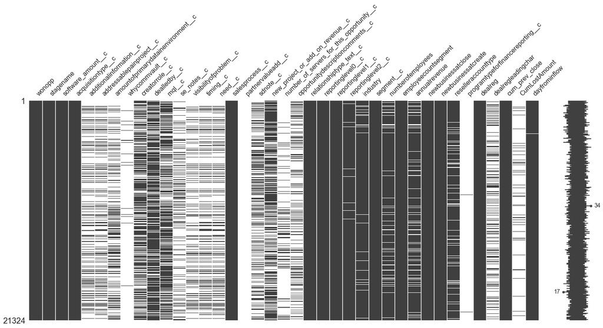

```python
msno.matrix(train);
```

Viewing columns in chart, some columns look to be completely missing data such as:

> whycommvaultc  
> partnervalueaddc  
> programtypeforfinancereporting__c

```python
train.drop(['whycommvault__c', 'partnervalueadd__c', 'programtypeforfinancereporting__c', 'stagename'], axis=1,inplace=True)
train.shape
```

```
(21324, 35)
```

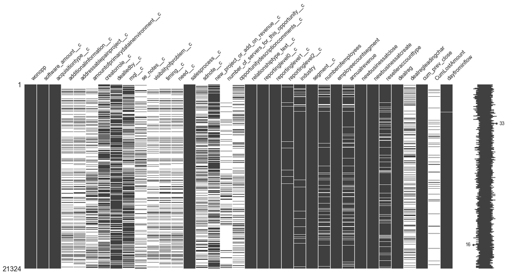

```python
msno.matrix(train);
```

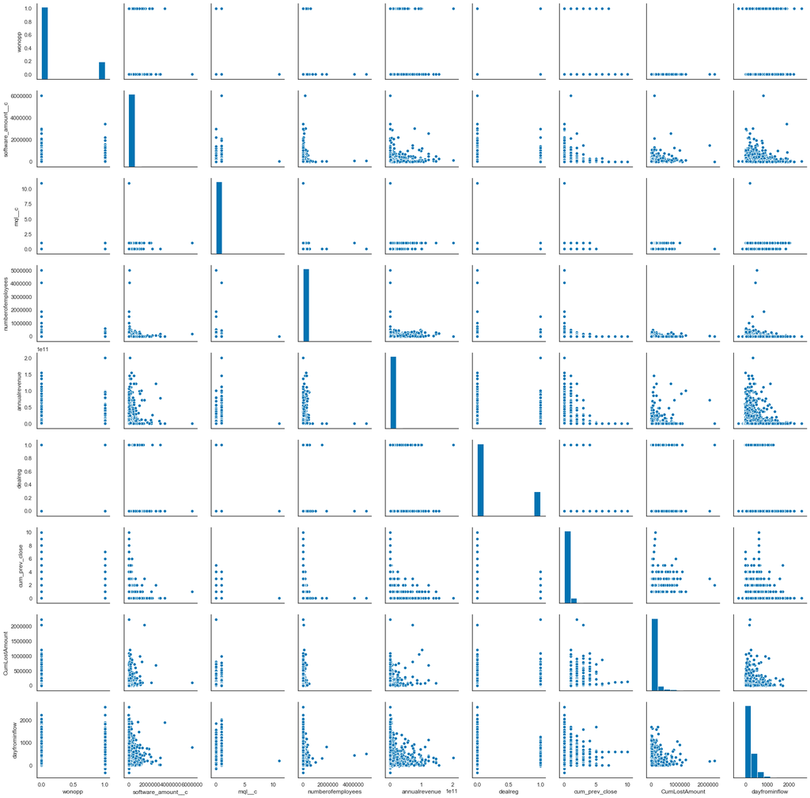

```python
sns.pairplot(train);
```

## Numerical versus Categorical Features

```python
#train.dtypes
```

```python
print("\nData Features Null\n")
na_totals = train.isnull().sum().sort_values(ascending=False)
na_totals_perc = train.isnull().sum().sort_values(ascending=False)/len(train)
print(na_totals[na_totals>0], "\n")
print(na_totals_perc[na_totals_perc>0])
```

```
Data Features Null

CumLostAmount                                19843
number_of_servers_for_this_opportunity__c    17597
visibilityofproblem__c                       16305
opportunitydescriptioncomments__c            16066
dealregleadingchar                           15962
additionalinformation__c                     15771
se_notes__c                                  15593
need__c                                      15586
addressablepainproject__c                    15505
timing__c                                    15390
amountofprimarydatainenvironment__c          13933
sdnote__c                                    12745
new_project_or_add_on_revenue__c              8302
creatorrole__c                                7967
mql__c                                        7602
dealledby__c                                  4385
annualrevenue                                 2910
numberofemployees                             2366
reselleraccounttype                           2190
industry                                      1086
reportinglevel2__c                             335
dayfrominflow                                   24
reportinglevel1__c                              17
reportinglevel0__c                              12
acquisitiontype__c                               8
relationshiptype_text__c                         7
salesprocess__c                                  1
dtype: int64

CumLostAmount                               0.93
number_of_servers_for_this_opportunity__c   0.83
visibilityofproblem__c                      0.76
opportunitydescriptioncomments__c           0.75
dealregleadingchar                          0.75
additionalinformation__c                    0.74
se_notes__c                                 0.73
need__c                                     0.73
addressablepainproject__c                   0.73
timing__c                                   0.72
amountofprimarydatainenvironment__c         0.65
sdnote__c                                   0.60
new_project_or_add_on_revenue__c            0.39
creatorrole__c                              0.37
mql__c                                      0.36
dealledby__c                                0.21
annualrevenue                               0.14
numberofemployees                           0.11
reselleraccounttype                         0.10
industry                                    0.05
reportinglevel2__c                          0.02
dayfrominflow                               0.00
reportinglevel1__c                          0.00
reportinglevel0__c                          0.00
acquisitiontype__c                          0.00
relationshiptype_text__c                    0.00
salesprocess__c                             0.00
dtype: float64
```

```python
kinds = np.array([dt.kind for dt in train.dtypes])
kinds
```

```
array(['i', 'f', 'O', 'O', 'O', 'O', 'O', 'O', 'f', 'O', 'O', 'O', 'O', 'O', 'O', 'O', 'O', 'O', 'O', 'O', 'O', 'O', 'O', 'O', 'f', 'O', 'f', 'O', 'O', 'O',
       'i', 'O', 'i', 'f', 'f'], dtype='<U1')
```

## numerical features

```python
all_columns = train.columns.values
is_num = kinds != 'O'
num_cols = all_columns[is_num]
num_cols
```

```
array(['wonopp', 'software_amount__c', 'mql__c', 'numberofemployees', 'annualrevenue', 'dealreg', 'cum_prev_close', 'CumLostAmount', 'dayfrominflow'],
      dtype=object)
```

## categorical features

```python
cat_cols = all_columns[~is_num]
cat_cols
```

```
array(['acquisitiontype__c', 'additionalinformation__c', 'addressablepainproject__c', 'amountofprimarydatainenvironment__c', 'creatorrole__c', 'dealledby__c',
       'se_notes__c', 'visibilityofproblem__c', 'timing__c', 'need__c', 'salesprocess__c', 'sdnote__c', 'new_project_or_add_on_revenue__c',
       'number_of_servers_for_this_opportunity__c', 'opportunitydescriptioncomments__c', 'relationshiptype_text__c', 'reportinglevel0__c',
       'reportinglevel1__c', 'reportinglevel2__c', 'industry', 'segment__c', 'employeecountsegment', 'newbusinessatclose', 'newbusinessatcreate',
       'reselleraccounttype', 'dealregleadingchar'], dtype=object)
```

# **Categorical Feature Engineering**

### Transformations and Encodings

Because we have categorical values, we need to represent these strings as numerical values in order to perform our classification with our models. Another method would be to use pandas. **One-Hot-Encodings**,

```python
print("categorical features:\n",cat_cols)
```

```
categorical features:
 ['acquisitiontype__c' 'additionalinformation__c' 'addressablepainproject__c' 'amountofprimarydatainenvironment__c' 'creatorrole__c' 'dealledby__c'
 'se_notes__c' 'visibilityofproblem__c' 'timing__c' 'need__c' 'salesprocess__c' 'sdnote__c' 'new_project_or_add_on_revenue__c'
 'number_of_servers_for_this_opportunity__c' 'opportunitydescriptioncomments__c' 'relationshiptype_text__c' 'reportinglevel0__c' 'reportinglevel1__c'
 'reportinglevel2__c' 'industry' 'segment__c' 'employeecountsegment' 'newbusinessatclose' 'newbusinessatcreate' 'reselleraccounttype' 'dealregleadingchar']
```

```python
# create cat dataframe to use for transformations and encoding
df_cat_tranform = train[cat_cols].copy()
df_cat_tranform = df_cat_tranform.reset_index(drop=True)
df_cat_tranform.head()
```

|  | acquisitiontype__c | additionalinformation__c | addressablepainproject__c | amountofprimarydatainenvironment__c | creatorrole__c | dealledby__c | se_notes__c | visibilityofproblem__c | timing__c | need__c | salesprocess__c | sdnote__c | new_project_or_add_on_revenue__c | number_of_servers_for_this_opportunity__c | opportunitydescriptioncomments__c | relationshiptype_text__c | reportinglevel0__c | reportinglevel1__c | reportinglevel2__c | industry | segment__c | employeecountsegment | newbusinessatclose | newbusinessatcreate | reselleraccounttype | dealregleadingchar |
| --- | --- | --- | --- | --- | --- | --- | --- | --- | --- | --- | --- | --- | --- | --- | --- | --- | --- | --- | --- | --- | --- | --- | --- | --- | --- | --- |
| 0 | Perpetual | NaN | NaN | NaN | Territory Account Manager | CVLT | NaN | NaN | NaN | NaN | Extended | no news | New Project | NaN | NaN | End User - Prospect | EMEA | Territory | Central | Technology | Mid-Market | D- 500 to 999 | Yes | Yes | Reseller-Contracted;End User - Prospect | NaN |
| 1 | Perpetual | NaN | NaN | NaN | Sales and Partner Administrator | Partner | NaN | NaN | NaN | NaN | Extended | Qualifying | New Project | NaN | El cliente desea revisar el backup de su organ... | End User - Prospect | Americas | US West & LATAM | Mexico | NaN | Blank | Unknown | Yes | Yes | Reseller-Contracted;Service Provider-Candidate | P |
| 2 | Perpetual | NaN | NaN | NaN | Territory Account Manager | Partner | NaN | NaN | NaN | NaN | Extended | Peter Dresbach is looking internal for PO\nFuj... | New Project | NaN | NaN | End User - Customer | EMEA | Territory | Central | Technology | Enterprise | B- 10 - 99 | Yes | Yes | OEM-Contracted;End User - Prospect | NaN |
| 3 | Perpetual | NaN | NaN | NaN | Inside Sales Representative | Partner & CVLT | NaN | NaN | NaN | NaN | Extended | PO received Commvault APAC | New Project | NaN | NaN | End User - Customer | EMEA | Large National | Israel & SSA | NaN | Blank | Unknown | Yes | Yes | OEM-Contracted | NaN |
| 4 | Perpetual | Background\n10 - 15 TB\non premise data being ... | GDPR Compliance and migration to the cloud | 11-15 TB | NaN | CVLT | NaN | Director | 4-6 Months | GDPR\nMigration to the cloud\nArchiving and in... | Extended | NaN | NaN | NaN | NaN | End User - Prospect | EMEA | Territory | Benelux | Education | Blank | D- 500 to 999 | Yes | Yes | Reseller-Contracted | NaN |

### acquisitiontype__c Na's

```python
acquisitiontype__c_count = df_cat_tranform.acquisitiontype__c.value_counts().count()
print("number of unique acquisitiontype__c_count", acquisitiontype__c_count)
```

```
number of unique acquisitiontype__c_count 5
```

```python
print("total missing values\n", df_cat_tranform.acquisitiontype__c.isnull().sum(),
      "\ntotal pcnt missing\n", df_cat_tranform.acquisitiontype__c.isnull().sum()/len(df_cat_tranform))
```

```
total missing values
 8
total pcnt missing
 0.00037516413430876007
```

```python
print(df_cat_tranform.acquisitiontype__c.value_counts())
```

```
Perpetual       20242
Subscription      821
Appliance         156
Utility            90
SaaS                7
Name: acquisitiontype__c, dtype: int64
```

```python
#from sklearn.impute import SimpleImputer

#using most frequent for missing acquistion type
acq_type__c_transf = np.array(df_cat_tranform[['acquisitiontype__c']]).reshape(-1, 1)
si = SimpleImputer(strategy='most_frequent')
df_cat_tranform['acquisitiontype__c'] = si.fit_transform(acq_type__c_transf)
```

```python
#from sklearn.preprocessing import OneHotEncoder

ohe = OneHotEncoder(sparse=False)
acq_type__c_transf = np.array(df_cat_tranform[['acquisitiontype__c']]).reshape(-1, 1)

acq_type__c_transf = ohe.fit_transform(acq_type__c_transf)

df_acq_type__c_transf = pd.DataFrame(acq_type__c_transf,
             columns=list(ohe.get_feature_names()))
df_acq_type__c_transf.sample(5)
```

|  | x0_Appliance | x0_Perpetual | x0_SaaS | x0_Subscription | x0_Utility |
| --- | --- | --- | --- | --- | --- |
| 19805 | 0.00 | 1.00 | 0.00 | 0.00 | 0.00 |
| 3374 | 0.00 | 1.00 | 0.00 | 0.00 | 0.00 |
| 17624 | 0.00 | 1.00 | 0.00 | 0.00 | 0.00 |
| 4324 | 0.00 | 1.00 | 0.00 | 0.00 | 0.00 |
| 18044 | 0.00 | 1.00 | 0.00 | 0.00 | 0.00 |

```python
feature_frames = []
feature_frames.append('df_acq_type__c_transf')
print(feature_frames)
```

```
['df_acq_type__c_transf']
```

### additionalinformation__c

```python
adtlinfo_count = df_cat_tranform.additionalinformation__c.value_counts().count()
print("number of unique additionalinformation__c\n", adtlinfo_count)
```

```
number of unique additionalinformation__c
 4786
```

```python
#replace values with exists or not
df_cat_tranform['additionalinformation__c'] = np.where(df_cat_tranform['additionalinformation__c'].isnull(),
                                                       'addinfo_exists', 'addinfo_not_exist')
```

```python
ohe = OneHotEncoder(sparse=False)
adtlinfo_transf = np.array(df_cat_tranform[['additionalinformation__c']]).reshape(-1, 1)

adtlinfo_transf = ohe.fit_transform(adtlinfo_transf)

df_adtlinfo_transf = pd.DataFrame(adtlinfo_transf,
             columns=list(ohe.get_feature_names()))
df_adtlinfo_transf.sample(5)
```

|  | x0_addinfo_exists | x0_addinfo_not_exist |
| --- | --- | --- |
| 19690 | 0.00 | 1.00 |
| 17949 | 1.00 | 0.00 |
| 2931 | 1.00 | 0.00 |
| 8785 | 1.00 | 0.00 |
| 10963 | 1.00 | 0.00 |

```python
feature_frames.append('df_adtlinfo_transf')
feature_frames
```

```
['df_acq_type__c_transf', 'df_adtlinfo_transf']
```

### addressablepainproject__c

```python
pain_count = df_cat_tranform.addressablepainproject__c.value_counts().count()
print("number of unique addressablepainproject__c\n", pain_count)
```

```
number of unique addressablepainproject__c
 4360
```

```python
#replace values with exists or not
df_cat_tranform['addressablepainproject__c'] = np.where(df_cat_tranform['addressablepainproject__c'].isnull(),
                                                       'pain_exists', 'pain_not_exist')
```

```python
ohe = OneHotEncoder(sparse=False)
pain_transf = np.array(df_cat_tranform[['addressablepainproject__c']]).reshape(-1, 1)

pain_transf = ohe.fit_transform(pain_transf)

df_pain_transf = pd.DataFrame(pain_transf,
             columns=list(ohe.get_feature_names()))
df_pain_transf.sample(5)
```

|  | x0_pain_exists | x0_pain_not_exist |
| --- | --- | --- |
| 5756 | 1.00 | 0.00 |
| 4202 | 1.00 | 0.00 |
| 1566 | 1.00 | 0.00 |
| 13807 | 1.00 | 0.00 |
| 10986 | 1.00 | 0.00 |

```python
feature_frames.append('df_pain_transf')
```

### amountofprimarydatainenvironment__c

```python
data_count = df_cat_tranform.amountofprimarydatainenvironment__c.value_counts().count()
print("number of unique amountofprimarydatainenvironment__c\n", data_count)
```

```
number of unique amountofprimarydatainenvironment__c
 16
```

```python
print("total unique values\n", df_cat_tranform.amountofprimarydatainenvironment__c.value_counts())
```

```
total unique values
 Greater than 50 TB    1582
Less than 5 TB        1436
6-10 TB               1376
11-15 TB               877
16-25 TB               865
26-50 TB               847
0 - 49                 288
50-99                   39
500+                    29
100-149                 23
150-299                 17
300-499                  8
无                        1
小于5TB                    1
1TB                      1
21-50                    1
Name: amountofprimarydatainenvironment__c, dtype: int64
```

```python
#df_cat_tranform['amountofprimarydatainenvironment__c'] = train['amountofprimarydatainenvironment__c']
```

```python
#replace null with 'unknown'
df_cat_tranform['amountofprimarydatainenvironment__c']= df_cat_tranform['amountofprimarydatainenvironment__c'].fillna(value='data_unknown')
```

```python
ohe = OneHotEncoder(sparse=False)
amtdata_transf = np.array(df_cat_tranform[['amountofprimarydatainenvironment__c']]).reshape(-1, 1)

amtdata_transf = ohe.fit_transform(amtdata_transf)

df_amtdata_transf = pd.DataFrame(amtdata_transf,
             columns=list(ohe.get_feature_names()))
df_amtdata_transf.sample(5)
```

|  | x0_0 - 49 | x0_100-149 | x0_11-15 TB | x0_150-299 | x0_16-25 TB | x0_1TB | x0_21-50 | x0_26-50 TB | x0_300-499 | x0_50-99 | x0_500+ | x0_6-10 TB | x0_Greater than 50 TB | x0_Less than 5 TB | x0_data_unknown | x0_小于5TB | x0_无 |
| --- | --- | --- | --- | --- | --- | --- | --- | --- | --- | --- | --- | --- | --- | --- | --- | --- | --- |
| 14778 | 1.00 | 0.00 | 0.00 | 0.00 | 0.00 | 0.00 | 0.00 | 0.00 | 0.00 | 0.00 | 0.00 | 0.00 | 0.00 | 0.00 | 0.00 | 0.00 | 0.00 |
| 16931 | 0.00 | 0.00 | 0.00 | 0.00 | 0.00 | 0.00 | 0.00 | 0.00 | 0.00 | 0.00 | 0.00 | 0.00 | 0.00 | 0.00 | 1.00 | 0.00 | 0.00 |
| 7949 | 0.00 | 0.00 | 0.00 | 0.00 | 0.00 | 0.00 | 0.00 | 0.00 | 0.00 | 0.00 | 0.00 | 0.00 | 0.00 | 0.00 | 1.00 | 0.00 | 0.00 |
| 3497 | 0.00 | 0.00 | 0.00 | 0.00 | 0.00 | 0.00 | 0.00 | 0.00 | 0.00 | 0.00 | 0.00 | 0.00 | 0.00 | 0.00 | 1.00 | 0.00 | 0.00 |
| 8481 | 0.00 | 0.00 | 0.00 | 0.00 | 0.00 | 0.00 | 0.00 | 0.00 | 0.00 | 0.00 | 0.00 | 0.00 | 0.00 | 0.00 | 1.00 | 0.00 | 0.00 |

```python
feature_frames.append('df_amtdata_transf')
```

### creatorrole__c

```python
data_count = df_cat_tranform.creatorrole__c.value_counts().count()
print("number of unique creatorrole__c\n", data_count)
```

```
number of unique creatorrole__c
 47
```

```python
print("total missing values\n", df_cat_tranform.creatorrole__c.isnull().sum(),
      "\ntotal pcnt missing\n", df_cat_tranform.creatorrole__c.isnull().sum()/len(df_cat_tranform))
```

```
total missing values
 7967
total pcnt missing
 0.37361658225473643
```

```python
#replace null with 'unknown'
df_cat_tranform['creatorrole__c']= df_cat_tranform['creatorrole__c'].fillna(value='creator_unknown')
```

```python
print("total unique values\n", df_cat_tranform.creatorrole__c.value_counts().count(),'\n',df_cat_tranform.creatorrole__c.value_counts())
```

```
total unique values
 48
 creator_unknown                                  7967
Sales and Partner Administrator                  3867
Enterprise Territory Manager                     2178
Inside Sales Representative                      1692
Inside Sales Administrator                       1033
Territory Account Manager                        1020
Enterprise Account Manager                        884
Inside Sales Representative, Commercial           879
Enterprise Account Executive                      521
Team Lead, Sales and Partner Administration       274
Inside Sales Representative, Enterprise           212
Partner Business Manager                          125
Key Account Executive                              81
District Channel Manager                           71
Sales Director                                     66
Associate Account Executive                        53
SMB Account Manager                                47
Systems Engineer                                   45
Sales Operations Team Lead                         33
Sales Manager                                      33
Partner Account Manager                            32
Sales Operations Analyst                           32
Inside Channel Account Manager                     27
Systems Engineer, Commercial                       16
Director, Sales Operations                         16
Director, WW Sales and Partner Administration      15
Senior CRM Analyst                                 13
CRM Administrator                                  11
Manager, Systems Engineering                       11
SI/Alliances Manager                               11
Area Vice President                                 8
Temporary, Sales                                    8
Manager, Sales Management                           7
Manager, Inside Sales                               6
Business Analyst                                    5
Director, Systems Engineering                       4
Sr. Systems Engineer, Commercial                    3
Senior Systems Engineer                             3
Solutions Specialist                                3
Administrative Assistant                            2
Senior Manager, Deal Desk                           2
Systems Engineer, Enterprise                        2
Solutions Architect                                 1
Dir. Global Systems Integrator                      1
Sales Director, Overlay                             1
Senior Vice President, Worldwide Sales              1
Principal Systems Engineer, Enterprise              1
Sales Enablement Specialist                         1
Name: creatorrole__c, dtype: int64
```

```python
ohe = OneHotEncoder(sparse=False)
creator_transf = np.array(df_cat_tranform[['creatorrole__c']]).reshape(-1, 1)

creator_transf = ohe.fit_transform(creator_transf)

df_creator_transf = pd.DataFrame(creator_transf,
             columns=list(ohe.get_feature_names()))
df_creator_transf.sample(2)
```

|  | x0_Administrative Assistant | x0_Area Vice President | x0_Associate Account Executive | x0_Business Analyst | x0_CRM Administrator | x0_Dir. Global Systems Integrator | x0_Director, Sales Operations | x0_Director, Systems Engineering | x0_Director, WW Sales and Partner Administration | x0_District Channel Manager | x0_Enterprise Account Executive | x0_Enterprise Account Manager | x0_Enterprise Territory Manager | x0_Inside Channel Account Manager | x0_Inside Sales Administrator | x0_Inside Sales Representative | x0_Inside Sales Representative, Commercial | x0_Inside Sales Representative, Enterprise | x0_Key Account Executive | x0_Manager, Inside Sales | x0_Manager, Sales Management | x0_Manager, Systems Engineering | x0_Partner Account Manager | x0_Partner Business Manager | x0_Principal Systems Engineer, Enterprise | x0_SI/Alliances Manager | x0_SMB Account Manager | x0_Sales Director | x0_Sales Director, Overlay | … |
| --- | --- | --- | --- | --- | --- | --- | --- | --- | --- | --- | --- | --- | --- | --- | --- | --- | --- | --- | --- | --- | --- | --- | --- | --- | --- | --- | --- | --- | --- | --- |
| 18994 | 0.00 | 0.00 | 0.00 | 0.00 | 0.00 | 0.00 | 0.00 | 0.00 | 0.00 | 0.00 | 0.00 | 0.00 | 0.00 | 0.00 | 0.00 | 0.00 | 0.00 | 0.00 | 0.00 | 0.00 | 0.00 | 0.00 | 0.00 | 0.00 | 0.00 | 0.00 | 0.00 | 0.00 | 0.00 | … |
| 7405 | 0.00 | 0.00 | 0.00 | 0.00 | 0.00 | 0.00 | 0.00 | 0.00 | 0.00 | 0.00 | 0.00 | 0.00 | 0.00 | 0.00 | 0.00 | 0.00 | 0.00 | 0.00 | 0.00 | 0.00 | 0.00 | 0.00 | 0.00 | 0.00 | 0.00 | 0.00 | 0.00 | 0.00 | 0.00 | … |

```python
y_train = train['wonopp']
X_train = df_creator_transf
```

## questionable review again

```python
#from dtreeviz.trees import *
#from IPython.display import Image, display_svg
#clf = tree.DecisionTreeClassifier(max_depth=3)
```

```python
clas = tree.DecisionTreeClassifier(max_depth=5)
#cancer = load_breast_cancer()

#X_train = X_train
#y_train = y_train
clas.fit(X_train, y_train)

# pick random X observation for demo
X = df_creator_transf.values[np.random.randint(0, len(df_creator_transf.values)),:]

viz = dtreeviz(clas,
               X_train,
               y_train,
               target_name='wonopp',
               feature_names=df_creator_transf.columns,
               class_names=["lost", "won"],
               histtype= 'barstacked',
              X=X)
viz
```

[figure not shown]

#### reduce classes by the results of the decision tree classification.

```python
df_cat_tranform['creatorrole__c'] = train['creatorrole__c']
#df_cat_tranform.head()
```

```python
df_cat_tranform['creatorrole__c']= df_cat_tranform['creatorrole__c'].fillna(value='creator_unknown')
names = df_cat_tranform['creatorrole__c'].value_counts()
names = list(pd.DataFrame(names).index)
names.remove('creator_unknown')
names.remove('Enterprise Territory Manager')
names.remove('Partner Business Manager')
names.remove('Enterprise Account Manager')
names.remove('Territory Account Manager')
replacewith = {x : 'not_ter_or_bus_mgr' for x in names} #create a dictionary with remaining names
df_cat_tranform['creatorrole__c'] = df_cat_tranform['creatorrole__c'].replace(replacewith)
```

```python
df_cat_tranform.head()
```

|  | acquisitiontype__c | additionalinformation__c | addressablepainproject__c | amountofprimarydatainenvironment__c | creatorrole__c | dealledby__c | se_notes__c | visibilityofproblem__c | timing__c | need__c | salesprocess__c | sdnote__c | new_project_or_add_on_revenue__c | number_of_servers_for_this_opportunity__c | opportunitydescriptioncomments__c | relationshiptype_text__c | reportinglevel0__c | reportinglevel1__c | reportinglevel2__c | industry | segment__c | employeecountsegment | newbusinessatclose | newbusinessatcreate | reselleraccounttype | dealregleadingchar |
| --- | --- | --- | --- | --- | --- | --- | --- | --- | --- | --- | --- | --- | --- | --- | --- | --- | --- | --- | --- | --- | --- | --- | --- | --- | --- | --- |
| 0 | Perpetual | addinfo_exists | pain_exists | data_unknown | Territory Account Manager | CVLT | NaN | NaN | NaN | NaN | Extended | no news | New Project | NaN | NaN | End User - Prospect | EMEA | Territory | Central | Technology | Mid-Market | D- 500 to 999 | Yes | Yes | Reseller-Contracted;End User - Prospect | NaN |
| 1 | Perpetual | addinfo_exists | pain_exists | data_unknown | not_ter_or_bus_mgr | Partner | NaN | NaN | NaN | NaN | Extended | Qualifying | New Project | NaN | El cliente desea revisar el backup de su organ... | End User - Prospect | Americas | US West & LATAM | Mexico | NaN | Blank | Unknown | Yes | Yes | Reseller-Contracted;Service Provider-Candidate | P |
| 2 | Perpetual | addinfo_exists | pain_exists | data_unknown | Territory Account Manager | Partner | NaN | NaN | NaN | NaN | Extended | Peter Dresbach is looking internal for PO\nFuj... | New Project | NaN | NaN | End User - Customer | EMEA | Territory | Central | Technology | Enterprise | B- 10 - 99 | Yes | Yes | OEM-Contracted;End User - Prospect | NaN |
| 3 | Perpetual | addinfo_exists | pain_exists | data_unknown | not_ter_or_bus_mgr | Partner & CVLT | NaN | NaN | NaN | NaN | Extended | PO received Commvault APAC | New Project | NaN | NaN | End User - Customer | EMEA | Large National | Israel & SSA | NaN | Blank | Unknown | Yes | Yes | OEM-Contracted | NaN |
| 4 | Perpetual | addinfo_not_exist | pain_not_exist | 11-15 TB | creator_unknown | CVLT | NaN | Director | 4-6 Months | GDPR\nMigration to the cloud\nArchiving and in... | Extended | NaN | NaN | NaN | NaN | End User - Prospect | EMEA | Territory | Benelux | Education | Blank | D- 500 to 999 | Yes | Yes | Reseller-Contracted | NaN |

```python
ohe = OneHotEncoder(sparse=False)
creator_transf = np.array(df_cat_tranform[['creatorrole__c']]).reshape(-1, 1)

creator_transf = ohe.fit_transform(creator_transf)

df_creator_transf = pd.DataFrame(creator_transf,
             columns=list(ohe.get_feature_names()))
df_creator_transf.sample(2)
```

|  | x0_Enterprise Account Manager | x0_Enterprise Territory Manager | x0_Partner Business Manager | x0_Territory Account Manager | x0_creator_unknown | x0_not_ter_or_bus_mgr |
| --- | --- | --- | --- | --- | --- | --- |
| 5005 | 0.00 | 1.00 | 0.00 | 0.00 | 0.00 | 0.00 |
| 2628 | 0.00 | 0.00 | 0.00 | 0.00 | 1.00 | 0.00 |

```python
feature_frames.append('df_creator_transf')
```

```python
df_cat_tranform['creatorrole__c'].value_counts()
```

```
not_ter_or_bus_mgr              9150
creator_unknown                 7967
Enterprise Territory Manager    2178
Territory Account Manager       1020
Enterprise Account Manager       884
Partner Business Manager         125
Name: creatorrole__c, dtype: int64
```

### dealledby__c

```python
data_count = df_cat_tranform.dealledby__c.value_counts().count()
print("number of unique dealledby__c\n", data_count)
print("total missing values\n", df_cat_tranform.dealledby__c.isnull().sum(),
      "\ntotal pcnt missing\n", df_cat_tranform.dealledby__c.isnull().sum()/len(df_cat_tranform))
```

```
number of unique dealledby__c
 4
total missing values
 4385
total pcnt missing
 0.20563684111798913
```

```python
df_cat_tranform.dealledby__c.value_counts()
```

```
CVLT              9768
Partner & CVLT    3845
Partner           3147
Unmanaged          179
Name: dealledby__c, dtype: int64
```

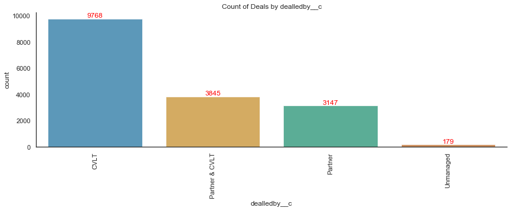

```python
dealledby__c_count = data.dealledby__c.value_counts().count()
g = sns.catplot('dealledby__c', data=df_cat_tranform, kind='count', alpha=0.7, height=4, aspect=3.0,
              order=df_cat_tranform.dealledby__c.value_counts().iloc[:dealledby__c_count].index)
g.set_xticklabels(rotation=90)
ax = plt.gca()
ax.set_title('Count of Deals by dealledby__c')
y_max = data['dealledby__c'].value_counts().max()

# Iterate through the list of axes' patches
for p in ax.patches:
    ax.text(p.get_x() + p.get_width()/2., p.get_height(), '%d' % int(p.get_height()),
            fontsize=12, color='red', ha='center', va='bottom')
```

```python
#Given large size of nan in leadby, **'unknown'** category will be created'
```

```python
dealledby_transf = np.array(df_cat_tranform[['dealledby__c']]).reshape(-1, 1)
si = SimpleImputer(strategy='constant', fill_value='ledby_MISSING')
dealledby_transf= si.fit_transform(dealledby_transf)

ohe = OneHotEncoder(sparse=False)
#acq_type__c_transf = np.array(df_cat_tranform[['acquisitiontype__c']]).reshape(-1, 1)

dealledby_transf = ohe.fit_transform(dealledby_transf)

df_dealledby_transf = pd.DataFrame(dealledby_transf,
             columns=list(ohe.get_feature_names()))
df_dealledby_transf.head()
```

|  | x0_CVLT | x0_Partner | x0_Partner & CVLT | x0_Unmanaged | x0_ledby_MISSING |
| --- | --- | --- | --- | --- | --- |
| 0 | 1.00 | 0.00 | 0.00 | 0.00 | 0.00 |
| 1 | 0.00 | 1.00 | 0.00 | 0.00 | 0.00 |
| 2 | 0.00 | 1.00 | 0.00 | 0.00 | 0.00 |
| 3 | 0.00 | 0.00 | 1.00 | 0.00 | 0.00 |
| 4 | 1.00 | 0.00 | 0.00 | 0.00 | 0.00 |

```python
feature_frames.append('df_dealledby_transf')
```

### se_notes__c

```python
data_count = df_cat_tranform.se_notes__c.value_counts().count()
print("number of unique se_notes__c\n", data_count)
print("total missing values\n", df_cat_tranform.se_notes__c.isnull().sum(),
      "\ntotal pcnt missing\n", df_cat_tranform.se_notes__c.isnull().sum()/len(df_cat_tranform))
```

```
number of unique se_notes__c
 5436
total missing values
 15593
total pcnt missing
 0.731241793284562
```

```python
#replace values with exists or not
df_cat_tranform['se_notes__c'] = np.where(df_cat_tranform['se_notes__c'].isnull(),
                                                       'se_note_exists', 'se_note_not_exist')
```

```python
se_notes_transf = np.array(df_cat_tranform[['se_notes__c']]).reshape(-1, 1)
si = SimpleImputer(strategy='constant', fill_value='se_notes_MISSING')
se_notes_transf= si.fit_transform(se_notes_transf)

ohe = OneHotEncoder(sparse=False)
#acq_type__c_transf = np.array(df_cat_tranform[['acquisitiontype__c']]).reshape(-1, 1)

se_notes_transf = ohe.fit_transform(se_notes_transf)

df_se_notes_transf = pd.DataFrame(se_notes_transf,
             columns=list(ohe.get_feature_names()))
df_se_notes_transf.head()
```

|  | x0_se_note_exists | x0_se_note_not_exist |
| --- | --- | --- |
| 0 | 1.00 | 0.00 |
| 1 | 1.00 | 0.00 |
| 2 | 1.00 | 0.00 |
| 3 | 1.00 | 0.00 |
| 4 | 1.00 | 0.00 |

```python
feature_frames.append('df_se_notes_transf')
```

### removing free texts fields with 70%+ missing

visibilityofproblemc  
number_of_servers_for_this_opportunityc  
opportunitydescriptioncomments__c

```python
remove_col = ['visibilityofproblem__c', 'number_of_servers_for_this_opportunity__c',
              'opportunitydescriptioncomments__c',]
# pandas drop columns using list of column names
df_cat_tranform.drop(remove_col, axis=1,inplace=True)
df_cat_tranform.shape
```

```
(21324, 23)
```

```python
data_count = df_cat_tranform.timing__c.value_counts().count()
print("number of unique timing__c\n", data_count)
print("total missing values\n", df_cat_tranform.timing__c.isnull().sum(),
      "\ntotal pcnt missing\n", df_cat_tranform.timing__c.isnull().sum()/len(df_cat_tranform))
```

```
number of unique timing__c
 12
total missing values
 15390
total pcnt missing
 0.7217220033764772
```

```python
df_cat_tranform.timing__c.value_counts()
```

```
0-3 Months     2679
4-6 Months     1828
7-12 Months    1283
12+ Months      124
1-3 months        8
3-6 months        3
<6 months         2
6-12 Months       2
> 1 Year          2
Immediately       1
0-6 months        1
Q2                1
Name: timing__c, dtype: int64
```

```python
#timing is missing too much data and unique values are not consistent
df_cat_tranform.drop('timing__c', axis=1,inplace=True)
```

### need__c

```python
data_count = df_cat_tranform.need__c.value_counts().count()
print("number of unique need__c\n", data_count)
print("total missing values\n", df_cat_tranform.need__c.isnull().sum(),
      "\ntotal pcnt missing\n", df_cat_tranform.need__c.isnull().sum()/len(df_cat_tranform))
```

```
number of unique need__c
 3360
total missing values
 15586
total pcnt missing
 0.7309135246670418
```

```python
#need__c is missing too much data and unique values are not consistent
df_cat_tranform.drop('need__c', axis=1,inplace=True)
```

### salesprocess__c

```python
data_count = df_cat_tranform.salesprocess__c.value_counts().count()
print("number of unique salesprocess__c\n", data_count)
print("total missing values\n", df_cat_tranform.salesprocess__c.isnull().sum(),
      "\ntotal pcnt missing\n", df_cat_tranform.salesprocess__c.isnull().sum()/len(df_cat_tranform))
```

```
number of unique salesprocess__c
 5
total missing values
 1
total pcnt missing
 4.689551678859501e-05
```

```python
df_cat_tranform.salesprocess__c.value_counts()
```

```
Extended            14006
Quick                6818
Add-on Only           311
Service Provider      123
Utility Billing        65
Name: salesprocess__c, dtype: int64
```

```python
salesprocess_transf = np.array(df_cat_tranform[['salesprocess__c']]).reshape(-1, 1)
si = SimpleImputer(strategy='most_frequent')
df_cat_tranform['salesprocess__c'] = si.fit_transform(salesprocess_transf)

ohe = OneHotEncoder(sparse=False)
salesprocess_transf = np.array(df_cat_tranform[['salesprocess__c']]).reshape(-1, 1)

salesprocess_transf = ohe.fit_transform(salesprocess_transf)

df_salesprocess_transf = pd.DataFrame(salesprocess_transf,
             columns=list(ohe.get_feature_names()))
df_salesprocess_transf.head()
```

|  | x0_Add-on Only | x0_Extended | x0_Quick | x0_Service Provider | x0_Utility Billing |
| --- | --- | --- | --- | --- | --- |
| 0 | 0.00 | 1.00 | 0.00 | 0.00 | 0.00 |
| 1 | 0.00 | 1.00 | 0.00 | 0.00 | 0.00 |
| 2 | 0.00 | 1.00 | 0.00 | 0.00 | 0.00 |
| 3 | 0.00 | 1.00 | 0.00 | 0.00 | 0.00 |
| 4 | 0.00 | 1.00 | 0.00 | 0.00 | 0.00 |

```python
feature_frames.append('df_salesprocess_transf')
```

### sdnote__c

```python
data_count = df_cat_tranform.sdnote__c.value_counts().count()
print("number of unique sdnote__c\n", data_count)
print("total missing values\n", df_cat_tranform.sdnote__c.isnull().sum(),
      "\ntotal pcnt missing\n", df_cat_tranform.sdnote__c.isnull().sum()/len(df_cat_tranform))
```

```
number of unique sdnote__c
 7561
total missing values
 12745
total pcnt missing
 0.5976833614706434
```

```python
#replace values with exists or not
df_cat_tranform['sdnote__c'] = np.where(df_cat_tranform['sdnote__c'].isnull(),
                                                       'sd_note_exists', 'sd_note_not_exist')
```

```python
sd_notes_transf = np.array(df_cat_tranform[['sdnote__c']]).reshape(-1, 1)
si = SimpleImputer(strategy='constant', fill_value='sd_notes_MISSING')
sd_notes_transf= si.fit_transform(sd_notes_transf)

ohe = OneHotEncoder(sparse=False)
#acq_type__c_transf = np.array(df_cat_tranform[['acquisitiontype__c']]).reshape(-1, 1)

sd_notes_transf = ohe.fit_transform(sd_notes_transf)

df_sd_notes_transf = pd.DataFrame(sd_notes_transf,
             columns=list(ohe.get_feature_names()))
df_sd_notes_transf.head()
```

|  | x0_sd_note_exists | x0_sd_note_not_exist |
| --- | --- | --- |
| 0 | 0.00 | 1.00 |
| 1 | 0.00 | 1.00 |
| 2 | 0.00 | 1.00 |
| 3 | 0.00 | 1.00 |
| 4 | 1.00 | 0.00 |

```python
feature_frames.append('df_sd_notes_transf')
```

### new_project_or_add_on_revenue__c

```python
data_count = df_cat_tranform.new_project_or_add_on_revenue__c.value_counts().count()
print("number of unique new_project_or_add_on_revenue__c\n", data_count)
print("total missing values\n", df_cat_tranform.new_project_or_add_on_revenue__c.isnull().sum(),
      "\ntotal pcnt missing\n", df_cat_tranform.new_project_or_add_on_revenue__c.isnull().sum()/len(df_cat_tranform))
```

```
number of unique new_project_or_add_on_revenue__c
 3
total missing values
 8302
total pcnt missing
 0.38932658037891577
```

```python
df_cat_tranform.new_project_or_add_on_revenue__c.value_counts()
```

```
New Project               12476
Add-on Revenue              542
Maintenance Conversion        4
Name: new_project_or_add_on_revenue__c, dtype: int64
```

```python
project_transf = np.array(df_cat_tranform[['new_project_or_add_on_revenue__c']]).reshape(-1, 1)
si = SimpleImputer(strategy='constant', fill_value='project_MISSING')
project_transf= si.fit_transform(project_transf)

ohe = OneHotEncoder(sparse=False)
#acq_type__c_transf = np.array(df_cat_tranform[['acquisitiontype__c']]).reshape(-1, 1)

project_transf = ohe.fit_transform(project_transf)

df_sproject_transf = pd.DataFrame(project_transf,
             columns=list(ohe.get_feature_names()))
df_sproject_transf.head()
```

|  | x0_Add-on Revenue | x0_Maintenance Conversion | x0_New Project | x0_project_MISSING |
| --- | --- | --- | --- | --- |
| 0 | 0.00 | 0.00 | 1.00 | 0.00 |
| 1 | 0.00 | 0.00 | 1.00 | 0.00 |
| 2 | 0.00 | 0.00 | 1.00 | 0.00 |
| 3 | 0.00 | 0.00 | 1.00 | 0.00 |
| 4 | 0.00 | 0.00 | 0.00 | 1.00 |

```python
feature_frames.append('df_sproject_transf')
```

### relationshiptype_text__c

```python
data_count = df_cat_tranform.relationshiptype_text__c.value_counts().count()
print("number of unique relationshiptype_text__c\n", data_count)
print("total missing values\n", df_cat_tranform.relationshiptype_text__c.isnull().sum(),
      "\ntotal pcnt missing\n", df_cat_tranform.relationshiptype_text__c.isnull().sum()/len(df_cat_tranform))
```

```
number of unique relationshiptype_text__c
 48
total missing values
 7
total pcnt missing
 0.0003282686175201651
```

```python
#df_cat_tranform.relationshiptype_text__c.value_counts()
```

```python
# create category based on first part of relationship type
df_cat_tranform['relationshiptype_text__c'] = df_cat_tranform['relationshiptype_text__c'].astype(str).str[:7]
```

```python
df_cat_tranform['relationshiptype_text__c'].value_counts()
```

```
End Use    20945
Reselle      172
Service      163
Aggrega       17
Allianc        9
nan            7
Distrib        6
OEM-Con        4
Systems        1
Name: relationshiptype_text__c, dtype: int64
```

```python
reltype_transf = np.array(df_cat_tranform[['relationshiptype_text__c']]).reshape(-1, 1)
si = SimpleImputer(strategy='constant', fill_value='reltype_MISSING')
reltype_transf= si.fit_transform(reltype_transf)

ohe = OneHotEncoder(sparse=False)
#acq_type__c_transf = np.array(df_cat_tranform[['acquisitiontype__c']]).reshape(-1, 1)

reltype_transf = ohe.fit_transform(reltype_transf)

df_reltype_transf = pd.DataFrame(reltype_transf,
             columns=list(ohe.get_feature_names()))
df_reltype_transf.head()
```

|  | x0_Aggrega | x0_Allianc | x0_Distrib | x0_End Use | x0_OEM-Con | x0_Reselle | x0_Service | x0_Systems | x0_nan |
| --- | --- | --- | --- | --- | --- | --- | --- | --- | --- |
| 0 | 0.00 | 0.00 | 0.00 | 1.00 | 0.00 | 0.00 | 0.00 | 0.00 | 0.00 |
| 1 | 0.00 | 0.00 | 0.00 | 1.00 | 0.00 | 0.00 | 0.00 | 0.00 | 0.00 |
| 2 | 0.00 | 0.00 | 0.00 | 1.00 | 0.00 | 0.00 | 0.00 | 0.00 | 0.00 |
| 3 | 0.00 | 0.00 | 0.00 | 1.00 | 0.00 | 0.00 | 0.00 | 0.00 | 0.00 |
| 4 | 0.00 | 0.00 | 0.00 | 1.00 | 0.00 | 0.00 | 0.00 | 0.00 | 0.00 |

```python
feature_frames.append('df_reltype_transf')
```

### reportinglevel0__c

```python
#df_cat_tranform.reportinglevel0__c = train.reportinglevel0__c
```

```python
reportinglevel0__c_count = df_cat_tranform.reportinglevel0__c.value_counts().count()
print("number of unique reportinglevel0__c", reportinglevel0__c_count)
print("total missing values\n", df_cat_tranform.reportinglevel0__c.isnull().sum(),
      "\ntotal pcnt missing\n", df_cat_tranform.reportinglevel0__c.isnull().sum()/len(df_cat_tranform))
```

```
number of unique reportinglevel0__c 4
total missing values
 12
total pcnt missing
 0.0005627462014631402
```

```python
reporting0_transf = np.array(df_cat_tranform[['reportinglevel0__c']]).reshape(-1, 1)
si = SimpleImputer(strategy='most_frequent')
df_cat_tranform['reportinglevel0__c'] = si.fit_transform(reporting0_transf)

ohe = OneHotEncoder(sparse=False)
reporting0_transf = np.array(df_cat_tranform[['reportinglevel0__c']]).reshape(-1, 1)

reporting0_transf = ohe.fit_transform(reporting0_transf)

df_reporting0_transf = pd.DataFrame(reporting0_transf,
             columns=list(ohe.get_feature_names()))
df_reporting0_transf.head()
```

|  | x0_APAC | x0_Americas | x0_EMEA | x0_GSI |
| --- | --- | --- | --- | --- |
| 0 | 0.00 | 0.00 | 1.00 | 0.00 |
| 1 | 0.00 | 1.00 | 0.00 | 0.00 |
| 2 | 0.00 | 0.00 | 1.00 | 0.00 |
| 3 | 0.00 | 0.00 | 1.00 | 0.00 |
| 4 | 0.00 | 0.00 | 1.00 | 0.00 |

```python
feature_frames.append('df_reporting0_transf')
```

### reportinglevel1__c

```python
#df_cat_tranform.reportinglevel1__c = train.reportinglevel1__c
```

```python
reportinglevel1__c_count = df_cat_tranform.reportinglevel1__c.value_counts().count()
print("number of unique reportinglevel0__c", reportinglevel1__c_count)
print("total missing values\n", df_cat_tranform.reportinglevel1__c.isnull().sum(),
      "\ntotal pcnt missing\n", df_cat_tranform.reportinglevel1__c.isnull().sum()/len(df_cat_tranform))
```

```
number of unique reportinglevel0__c 20
total missing values
 17
total pcnt missing
 0.0007972237854061152
```

```python
reporting1_transf = np.array(df_cat_tranform[['reportinglevel1__c']]).reshape(-1, 1)
si = SimpleImputer(strategy='constant', fill_value='rep1_MISSING')
reporting1_transf= si.fit_transform(reporting1_transf)

ohe = OneHotEncoder(sparse=False)
#acq_type__c_transf = np.array(df_cat_tranform[['acquisitiontype__c']]).reshape(-1, 1)

reporting1_transf = ohe.fit_transform(reporting1_transf)

df_reporting1_transf = pd.DataFrame(reporting1_transf,
             columns=list(ohe.get_feature_names()))
df_reporting1_transf.head()
```

|  | x0_ANZ | x0_ASEAN | x0_Canada | x0_Channel | x0_China | x0_East Europe | x0_Global Enterprise | x0_India | x0_Japan | x0_Korea | x0_Large National | x0_MESAT | x0_North-West Europe | x0_Public Sector | x0_SP | x0_South Europe | x0_Territory | x0_US East | x0_US West & LATAM | x0_Unallocated | x0_rep1_MISSING |
| --- | --- | --- | --- | --- | --- | --- | --- | --- | --- | --- | --- | --- | --- | --- | --- | --- | --- | --- | --- | --- | --- |
| 0 | 0.00 | 0.00 | 0.00 | 0.00 | 0.00 | 0.00 | 0.00 | 0.00 | 0.00 | 0.00 | 0.00 | 0.00 | 0.00 | 0.00 | 0.00 | 0.00 | 1.00 | 0.00 | 0.00 | 0.00 | 0.00 |
| 1 | 0.00 | 0.00 | 0.00 | 0.00 | 0.00 | 0.00 | 0.00 | 0.00 | 0.00 | 0.00 | 0.00 | 0.00 | 0.00 | 0.00 | 0.00 | 0.00 | 0.00 | 0.00 | 1.00 | 0.00 | 0.00 |
| 2 | 0.00 | 0.00 | 0.00 | 0.00 | 0.00 | 0.00 | 0.00 | 0.00 | 0.00 | 0.00 | 0.00 | 0.00 | 0.00 | 0.00 | 0.00 | 0.00 | 1.00 | 0.00 | 0.00 | 0.00 | 0.00 |
| 3 | 0.00 | 0.00 | 0.00 | 0.00 | 0.00 | 0.00 | 0.00 | 0.00 | 0.00 | 0.00 | 1.00 | 0.00 | 0.00 | 0.00 | 0.00 | 0.00 | 0.00 | 0.00 | 0.00 | 0.00 | 0.00 |
| 4 | 0.00 | 0.00 | 0.00 | 0.00 | 0.00 | 0.00 | 0.00 | 0.00 | 0.00 | 0.00 | 0.00 | 0.00 | 0.00 | 0.00 | 0.00 | 0.00 | 1.00 | 0.00 | 0.00 | 0.00 | 0.00 |

```python
feature_frames.append('df_reporting1_transf')
```

### reportinglevel2__c

```python
#df_cat_tranform.reportinglevel2__c = train.reportinglevel2__c
```

```python
count = df_cat_tranform.reportinglevel2__c.value_counts().count()
print("number of unique reportinglevel2__c", count)
print("total missing values\n", df_cat_tranform.reportinglevel2__c.isnull().sum(),
      "\ntotal pcnt missing\n", df_cat_tranform.reportinglevel2__c.isnull().sum()/len(df_cat_tranform))
```

```
number of unique reportinglevel2__c 58
total missing values
 335
total pcnt missing
 0.01570999812417933
```

```python
reporting2_transf = np.array(df_cat_tranform[['reportinglevel2__c']]).reshape(-1, 1)
si = SimpleImputer(strategy='constant', fill_value='rep2_MISSING')
reporting2_transf= si.fit_transform(reporting2_transf)

ohe = OneHotEncoder(sparse=False)
#acq_type__c_transf = np.array(df_cat_tranform[['acquisitiontype__c']]).reshape(-1, 1)

reporting2_transf = ohe.fit_transform(reporting2_transf)

df_reporting2_transf = pd.DataFrame(reporting2_transf,
             columns=list(ohe.get_feature_names()))
df_reporting2_transf.head()
```

|  | x0_Aggregation | x0_Alliances | x0_Benelux | x0_Brazil | x0_CIS | x0_Canada Central & West | x0_Canada East | x0_Central | x0_Central & UKI | x0_Central-South | x0_Channel | x0_Civilian | x0_Direct | x0_Distribution | x0_DoD | x0_EE | x0_FIS | x0_France | x0_Geo | x0_Gov | x0_Gulf | x0_HKTW | x0_ID | x0_IOC | x0_Iberia | x0_Israel & SSA | x0_Italy | x0_KSA | x0_MY | … |
| --- | --- | --- | --- | --- | --- | --- | --- | --- | --- | --- | --- | --- | --- | --- | --- | --- | --- | --- | --- | --- | --- | --- | --- | --- | --- | --- | --- | --- | --- | --- |
| 0 | 0.00 | 0.00 | 0.00 | 0.00 | 0.00 | 0.00 | 0.00 | 1.00 | 0.00 | 0.00 | 0.00 | 0.00 | 0.00 | 0.00 | 0.00 | 0.00 | 0.00 | 0.00 | 0.00 | 0.00 | 0.00 | 0.00 | 0.00 | 0.00 | 0.00 | 0.00 | 0.00 | 0.00 | 0.00 | … |
| 1 | 0.00 | 0.00 | 0.00 | 0.00 | 0.00 | 0.00 | 0.00 | 0.00 | 0.00 | 0.00 | 0.00 | 0.00 | 0.00 | 0.00 | 0.00 | 0.00 | 0.00 | 0.00 | 0.00 | 0.00 | 0.00 | 0.00 | 0.00 | 0.00 | 0.00 | 0.00 | 0.00 | 0.00 | 0.00 | … |
| 2 | 0.00 | 0.00 | 0.00 | 0.00 | 0.00 | 0.00 | 0.00 | 1.00 | 0.00 | 0.00 | 0.00 | 0.00 | 0.00 | 0.00 | 0.00 | 0.00 | 0.00 | 0.00 | 0.00 | 0.00 | 0.00 | 0.00 | 0.00 | 0.00 | 0.00 | 0.00 | 0.00 | 0.00 | 0.00 | … |
| 3 | 0.00 | 0.00 | 0.00 | 0.00 | 0.00 | 0.00 | 0.00 | 0.00 | 0.00 | 0.00 | 0.00 | 0.00 | 0.00 | 0.00 | 0.00 | 0.00 | 0.00 | 0.00 | 0.00 | 0.00 | 0.00 | 0.00 | 0.00 | 0.00 | 0.00 | 1.00 | 0.00 | 0.00 | 0.00 | … |
| 4 | 0.00 | 0.00 | 1.00 | 0.00 | 0.00 | 0.00 | 0.00 | 0.00 | 0.00 | 0.00 | 0.00 | 0.00 | 0.00 | 0.00 | 0.00 | 0.00 | 0.00 | 0.00 | 0.00 | 0.00 | 0.00 | 0.00 | 0.00 | 0.00 | 0.00 | 0.00 | 0.00 | 0.00 | 0.00 | … |

```python
feature_frames.append('df_reporting2_transf')
```

## industry

```python
industry_count = df_cat_tranform.industry.value_counts().count()
print("number of unique industry_count", industry_count)
print("total missing values\n", df_cat_tranform.industry.isnull().sum(),
      "\ntotal pcnt missing\n", df_cat_tranform.industry.isnull().sum()/len(df_cat_tranform))
```

```
number of unique industry_count 19
total missing values
 1086
total pcnt missing
 0.050928531232414184
```

```python
ohe = OneHotEncoder(sparse=False)
industry_transf = np.array(df_cat_tranform[['industry']]).reshape(-1, 1)
si = SimpleImputer(strategy='constant', fill_value='ind_MISSING')
industry_transf = si.fit_transform(industry_transf)
```

```python
#acq_type__c_transf = np.array(df_cat_tranform[['acquisitiontype__c']]).reshape(-1, 1)
industry_transf = ohe.fit_transform(industry_transf)
df_industry_transf = pd.DataFrame(industry_transf,
             columns=list(ohe.get_feature_names()))
df_industry_transf.head()
```

|  | x0_Agriculture | x0_Banking & Insurance | x0_Chemicals | x0_Communications | x0_Construction | x0_Consulting | x0_Education | x0_Government | x0_Healthcare | x0_Hospitality | x0_Legal | x0_Manufacturing | x0_Media | x0_Other | x0_Recreation | x0_Technology | x0_Transportation | x0_Utilities | x0_Wholesale & Retail | x0_ind_MISSING |
| --- | --- | --- | --- | --- | --- | --- | --- | --- | --- | --- | --- | --- | --- | --- | --- | --- | --- | --- | --- | --- |
| 0 | 0.00 | 0.00 | 0.00 | 0.00 | 0.00 | 0.00 | 0.00 | 0.00 | 0.00 | 0.00 | 0.00 | 0.00 | 0.00 | 0.00 | 0.00 | 1.00 | 0.00 | 0.00 | 0.00 | 0.00 |
| 1 | 0.00 | 0.00 | 0.00 | 0.00 | 0.00 | 0.00 | 0.00 | 0.00 | 0.00 | 0.00 | 0.00 | 0.00 | 0.00 | 0.00 | 0.00 | 0.00 | 0.00 | 0.00 | 0.00 | 1.00 |
| 2 | 0.00 | 0.00 | 0.00 | 0.00 | 0.00 | 0.00 | 0.00 | 0.00 | 0.00 | 0.00 | 0.00 | 0.00 | 0.00 | 0.00 | 0.00 | 1.00 | 0.00 | 0.00 | 0.00 | 0.00 |
| 3 | 0.00 | 0.00 | 0.00 | 0.00 | 0.00 | 0.00 | 0.00 | 0.00 | 0.00 | 0.00 | 0.00 | 0.00 | 0.00 | 0.00 | 0.00 | 0.00 | 0.00 | 0.00 | 0.00 | 1.00 |
| 4 | 0.00 | 0.00 | 0.00 | 0.00 | 0.00 | 0.00 | 1.00 | 0.00 | 0.00 | 0.00 | 0.00 | 0.00 | 0.00 | 0.00 | 0.00 | 0.00 | 0.00 | 0.00 | 0.00 | 0.00 |

```python
feature_frames.append('df_industry_transf')
```

### segment__c

```python
segment__c_count = df_cat_tranform.segment__c.value_counts().count()
print("number of unique segment__c", segment__c_count)
print("total missing values\n", df_cat_tranform.segment__c.isnull().sum(),
      "\ntotal pcnt missing\n", df_cat_tranform.segment__c.isnull().sum()/len(df_cat_tranform))
```

```
number of unique segment__c 5
total missing values
 0
total pcnt missing
 0.0
```

```python
ohe = OneHotEncoder(sparse=False)
segment_transf = np.array(df_cat_tranform[['segment__c']]).reshape(-1, 1)
si = SimpleImputer(strategy='constant', fill_value='seg_MISSING')
segment_transf = si.fit_transform(segment_transf)

segment_transf = ohe.fit_transform(segment_transf)
df_segment_transf = pd.DataFrame(segment_transf,
             columns=list(ohe.get_feature_names()))
df_segment_transf.head()
```

|  | x0_Blank | x0_Enterprise | x0_Large Enterprise | x0_Mid-Market | x0_SMB |
| --- | --- | --- | --- | --- | --- |
| 0 | 0.00 | 0.00 | 0.00 | 1.00 | 0.00 |
| 1 | 1.00 | 0.00 | 0.00 | 0.00 | 0.00 |
| 2 | 0.00 | 1.00 | 0.00 | 0.00 | 0.00 |
| 3 | 1.00 | 0.00 | 0.00 | 0.00 | 0.00 |
| 4 | 1.00 | 0.00 | 0.00 | 0.00 | 0.00 |

```python
feature_frames.append('df_segment_transf')
```

### employeecountsegment

```python
employeecountsegment_count = df_cat_tranform.employeecountsegment.value_counts().count()
print("number of unique employeecountsegment", employeecountsegment_count)
print("total missing values\n", df_cat_tranform.employeecountsegment.isnull().sum(),
      "\ntotal pcnt missing\n", df_cat_tranform.employeecountsegment.isnull().sum()/len(df_cat_tranform))
```

```
number of unique employeecountsegment 6
total missing values
 0
total pcnt missing
 0.0
```

```python
ohe = OneHotEncoder(sparse=False)
employeecountsegment_transf = np.array(df_cat_tranform[['employeecountsegment']]).reshape(-1, 1)
si = SimpleImputer(strategy='constant', fill_value='emseg_MISSING')
employeecountsegment_transf = si.fit_transform(employeecountsegment_transf)

employeecountsegment_transf = ohe.fit_transform(employeecountsegment_transf)
df_employeecountsegment_transf = pd.DataFrame(employeecountsegment_transf,
             columns=list(ohe.get_feature_names()))
df_employeecountsegment_transf.head()
```

|  | x0_A- 1 to 9 | x0_B- 10 - 99 | x0_C- 100 to 499 | x0_D- 500 to 999 | x0_E- 1000+ | x0_Unknown |
| --- | --- | --- | --- | --- | --- | --- |
| 0 | 0.00 | 0.00 | 0.00 | 1.00 | 0.00 | 0.00 |
| 1 | 0.00 | 0.00 | 0.00 | 0.00 | 0.00 | 1.00 |
| 2 | 0.00 | 1.00 | 0.00 | 0.00 | 0.00 | 0.00 |
| 3 | 0.00 | 0.00 | 0.00 | 0.00 | 0.00 | 1.00 |
| 4 | 0.00 | 0.00 | 0.00 | 1.00 | 0.00 | 0.00 |

```python
feature_frames.append('df_employeecountsegment_transf')
```

### newbusinessatclose

```python
count = df_cat_tranform.newbusinessatclose.value_counts().count()
print("number of unique newbusinessatclose", count)
print("total missing values\n", df_cat_tranform.newbusinessatclose.isnull().sum(),
      "\ntotal pcnt missing\n", df_cat_tranform.newbusinessatclose.isnull().sum()/len(df_cat_tranform))
```

```
number of unique newbusinessatclose 1
total missing values
 0
total pcnt missing
 0.0
```

#### there is only one value for this feature, do not include = newbusinessatclose

```python
ohe = OneHotEncoder(sparse=False)
newbusinessatclose_transf = np.array(df_cat_tranform[['newbusinessatclose']]).reshape(-1, 1)
si = SimpleImputer(strategy='constant', fill_value='newbcount_MISSING')
newbusinessatclose_transf = si.fit_transform(newbusinessatclose_transf)

newbusinessatclose_transf = ohe.fit_transform(newbusinessatclose_transf)
df_newbusinessatclose_transf = pd.DataFrame(newbusinessatclose_transf,
             columns=list(ohe.get_feature_names()))
df_newbusinessatclose_transf.head()
```

|  | x0_Yes |
| --- | --- |
| 0 | 1.00 |
| 1 | 1.00 |
| 2 | 1.00 |
| 3 | 1.00 |
| 4 | 1.00 |

### newbusinessatcreate

```python
count = df_cat_tranform.newbusinessatcreate.value_counts().count()
print("number of unique newbusinessatcreate", count)
print("total missing values\n", df_cat_tranform.newbusinessatcreate.isnull().sum(),
      "\ntotal pcnt missing\n", df_cat_tranform.newbusinessatcreate.isnull().sum()/len(df_cat_tranform))
```

```
number of unique newbusinessatcreate 2
total missing values
 0
total pcnt missing
 0.0
```

```python
df_cat_tranform.newbusinessatcreate.value_counts()
```

```
Yes    20975
No       349
Name: newbusinessatcreate, dtype: int64
```

```python
ohe = OneHotEncoder(sparse=False)
newbusinessatcreate_transf = np.array(df_cat_tranform[['newbusinessatcreate']]).reshape(-1, 1)
si = SimpleImputer(strategy='constant', fill_value='newcrcount_MISSING')
newbusinessatcreate_transf = si.fit_transform(newbusinessatcreate_transf)

newbusinessatcreate_transf = ohe.fit_transform(newbusinessatcreate_transf)
df_newbusinessatcreate_transf = pd.DataFrame(newbusinessatcreate_transf,
             columns=list(ohe.get_feature_names()))
df_newbusinessatcreate_transf.head()
```

|  | x0_No | x0_Yes |
| --- | --- | --- |
| 0 | 0.00 | 1.00 |
| 1 | 0.00 | 1.00 |
| 2 | 0.00 | 1.00 |
| 3 | 0.00 | 1.00 |
| 4 | 0.00 | 1.00 |

```python
feature_frames.append('df_newbusinessatcreate_transf')
```

### reselleraccounttype

```python
count = df_cat_tranform.reselleraccounttype.value_counts().count()
print("number of unique reselleraccounttype", count)
print("total missing values\n", df_cat_tranform.reselleraccounttype.isnull().sum(),
      "\ntotal pcnt missing\n", df_cat_tranform.reselleraccounttype.isnull().sum()/len(df_cat_tranform))
```

```
number of unique reselleraccounttype 67
total missing values
 2190
total pcnt missing
 0.10270118176702307
```

```python
df_cat_tranform['reselleraccounttype']= df_cat_tranform['reselleraccounttype'].fillna(value='resellertype_unknown')
```

```python
names = df_cat_tranform['reselleraccounttype'].value_counts()
names = list(pd.DataFrame(names).index)
```

```python
#reducing the class to those with 450 or more occurances
names.remove('resellertype_unknown')
names.remove('Reseller-Contracted')
names.remove('Reseller-Contracted;End User - Prospect')
names.remove('Reseller-Contracted;Service Provider-Candidate')
names.remove('Reseller-Contracted;End User - Customer')
names.remove('Reseller-Contracted;Service Provider-Contracted')
replacewith = {x : 'other_reseller_type' for x in names} #create a dictionary with remaining names
df_cat_tranform['reselleraccounttype'] = df_cat_tranform['reselleraccounttype'].replace(replacewith)
```

```python
print(df_cat_tranform.reselleraccounttype.value_counts())
```

```
Reseller-Contracted                                8008
Reseller-Contracted;End User - Prospect            7172
resellertype_unknown                               2190
other_reseller_type                                1965
Reseller-Contracted;Service Provider-Candidate      881
Reseller-Contracted;End User - Customer             653
Reseller-Contracted;Service Provider-Contracted     455
Name: reselleraccounttype, dtype: int64
```

```python
count = df_cat_tranform.reselleraccounttype.value_counts().count()
print("number of unique reselleraccounttype", count)
print("total missing values\n", df_cat_tranform.reselleraccounttype.isnull().sum(),
      "\ntotal pcnt missing\n", df_cat_tranform.reselleraccounttype.isnull().sum()/len(df_cat_tranform))
```

```
number of unique reselleraccounttype 7
total missing values
 0
total pcnt missing
 0.0
```

```python
ohe = OneHotEncoder(sparse=False)
reselleraccounttype_transf = np.array(df_cat_tranform[['reselleraccounttype']]).reshape(-1, 1)
si = SimpleImputer(strategy='constant', fill_value='resellertype_MISSING')
reselleraccounttype_transf = si.fit_transform(reselleraccounttype_transf)

reselleraccounttype_transf = ohe.fit_transform(reselleraccounttype_transf)
df_reselleraccounttype_transf = pd.DataFrame(reselleraccounttype_transf,
             columns=list(ohe.get_feature_names()))
df_reselleraccounttype_transf.head()
```

|  | x0_Reseller-Contracted | x0_Reseller-Contracted;End User - Customer | x0_Reseller-Contracted;End User - Prospect | x0_Reseller-Contracted;Service Provider-Candidate | x0_Reseller-Contracted;Service Provider-Contracted | x0_other_reseller_type | x0_resellertype_unknown |
| --- | --- | --- | --- | --- | --- | --- | --- |
| 0 | 0.00 | 0.00 | 1.00 | 0.00 | 0.00 | 0.00 | 0.00 |
| 1 | 0.00 | 0.00 | 0.00 | 1.00 | 0.00 | 0.00 | 0.00 |
| 2 | 0.00 | 0.00 | 0.00 | 0.00 | 0.00 | 1.00 | 0.00 |
| 3 | 0.00 | 0.00 | 0.00 | 0.00 | 0.00 | 1.00 | 0.00 |
| 4 | 1.00 | 0.00 | 0.00 | 0.00 | 0.00 | 0.00 | 0.00 |

```python
feature_frames.append('df_reselleraccounttype_transf')
```

### dealregleadingchar

```python
#df_cat_tranform.dealregleadingchar = train.dealregleadingchar
```

```python
count = df_cat_tranform.dealregleadingchar.value_counts().count()
print("number of unique dealregleadingchar", count)
print("total missing values\n", df_cat_tranform.dealregleadingchar.isnull().sum(),
      "\ntotal pcnt missing\n", df_cat_tranform.dealregleadingchar.isnull().sum()/len(df_cat_tranform))
```

```
number of unique dealregleadingchar 3
total missing values
 15962
total pcnt missing
 0.7485462389795535
```

```python
print(df_cat_tranform.dealregleadingchar.value_counts())
```

```
P    2717
T    1854
C     791
Name: dealregleadingchar, dtype: int64
```

```python
ohe = OneHotEncoder(sparse=False)
dealreg_transf = np.array(df_cat_tranform[['dealregleadingchar']]).reshape(-1, 1)
si = SimpleImputer(strategy='constant', fill_value='dealreg_MISSING')
dealreg_transf = si.fit_transform(dealreg_transf)

dealreg_transf = ohe.fit_transform(dealreg_transf)
df_dealreg_transf = pd.DataFrame(dealreg_transf,
             columns=list(ohe.get_feature_names()))
df_dealreg_transf.head()
```

|  | x0_C | x0_P | x0_T | x0_dealreg_MISSING |
| --- | --- | --- | --- | --- |
| 0 | 0.00 | 0.00 | 0.00 | 1.00 |
| 1 | 0.00 | 1.00 | 0.00 | 0.00 |
| 2 | 0.00 | 0.00 | 0.00 | 1.00 |
| 3 | 0.00 | 0.00 | 0.00 | 1.00 |
| 4 | 0.00 | 0.00 | 0.00 | 1.00 |

```python
feature_frames.append('df_dealreg_transf')
```

```python
len(feature_frames)
```

```
20
```

```python
#msno.matrix(df_cat_tranform);
```

# **Numerical Feature Engineering**

```python
print("Numerical features:\n",num_cols)
```

```
Numerical features:
 ['wonopp' 'software_amount__c' 'mql__c' 'numberofemployees' 'annualrevenue' 'dealreg' 'cum_prev_close' 'CumLostAmount' 'dayfrominflow']
```

```python
df_num_tranform = train[num_cols].copy()
df_num_tranform = df_num_tranform.reset_index(drop=True)
df_num_tranform.head()
```

|  | wonopp | software_amount__c | mql__c | numberofemployees | annualrevenue | dealreg | cum_prev_close | CumLostAmount | dayfrominflow |
| --- | --- | --- | --- | --- | --- | --- | --- | --- | --- |
| 0 | 0 | 10,000.00 | nan | 780.00 | 95,022,752.00 | 0 | 0 | nan | 432.00 |
| 1 | 0 | 14,000.00 | 0.00 | nan | nan | 1 | 0 | nan | 127.00 |
| 2 | 1 | 23,368.00 | nan | 0.00 | 0.00 | 0 | 0 | nan | 8.00 |
| 3 | 1 | 17,965.66 | nan | nan | nan | 0 | 0 | nan | 89.00 |
| 4 | 0 | 3,000.00 | 1.00 | 500.00 | nan | 0 | 0 | nan | 28.00 |

```python
#view
group_wonopp = df_num_tranform.groupby(('wonopp'))
group_wonopp.describe()
```

| wonopp | software_amount__c count | software_amount__c mean | software_amount__c std | software_amount__c min | software_amount__c 25% | software_amount__c 50% | software_amount__c 75% | software_amount__c max | mql__c count | mql__c mean | mql__c std | mql__c min | mql__c 25% | mql__c 50% | mql__c 75% | mql__c max | numberofemployees count | numberofemployees mean | numberofemployees std | numberofemployees min | numberofemployees 25% | numberofemployees 50% | numberofemployees 75% | numberofemployees max | annualrevenue count | annualrevenue mean | annualrevenue std | annualrevenue min | annualrevenue 25% | … |
| --- | --- | --- | --- | --- | --- | --- | --- | --- | --- | --- | --- | --- | --- | --- | --- | --- | --- | --- | --- | --- | --- | --- | --- | --- | --- | --- | --- | --- | --- | --- |
| 0 | 17,147.00 | 41,328.36 | 108,005.25 | 1,001.00 | 7,225.50 | 15,000.00 | 40,000.00 | 6,000,000.00 | 11,951.00 | 0.49 | 0.51 | 0.00 | 0.00 | 0.00 | 1.00 | 11.00 | 15,413.00 | 5,822.45 | 60,818.13 | 0.00 | 51.00 | 380.00 | 1,800.00 | 5,000,000.00 | 14,957.00 | 1,342,490,859.84 | 7,462,311,484.94 | -67,415,276.00 | 0.00 | … |
| 1 | 4,177.00 | 37,648.93 | 116,257.23 | 1,007.48 | 4,837.95 | 10,770.72 | 29,091.83 | 3,428,398.82 | 1,771.00 | 0.36 | 0.48 | 0.00 | 0.00 | 0.00 | 1.00 | 1.00 | 3,545.00 | 3,680.56 | 21,640.10 | 0.00 | 28.00 | 276.00 | 1,200.00 | 588,902.00 | 3,457.00 | 932,486,343.51 | 6,312,786,837.21 | 0.00 | 0.00 | … |

```python
#remove prediction target
y = df_num_tranform.pop('wonopp').values
```

### software_amount__c

```python
print("total missing values\n", df_num_tranform.software_amount__c.isnull().sum(),
      "\ntotal pcnt missing\n", df_num_tranform.software_amount__c.isnull().sum()/len(data))
```

```
total missing values
 0
total pcnt missing
 0.0
```

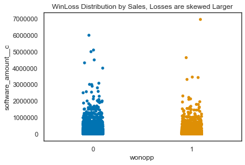

```python
plt.title("WinLoss Distribution by Sales, Losses are skewed Larger")
sns.stripplot(x="wonopp", y="software_amount__c", data=data, jitter=True);
```

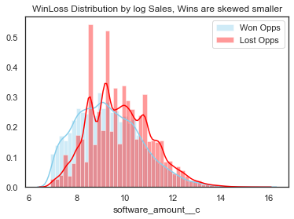

```python
# Method 1: on the same Axis
sns.despine(left=True)
plt.title("WinLoss Distribution by log Sales, Wins are skewed smaller")
sns.distplot( np.log(data[data.wonopp == 1]["software_amount__c"]) , color="skyblue", label="Won Opps")
sns.distplot( np.log(data[data.wonopp == 0]["software_amount__c"]) , color="red", label="Lost Opps");
plt.legend();
```

```python
from sklearn.preprocessing import StandardScaler
scaler = StandardScaler()
```

```python
software_amount_transf = np.array(df_num_tranform["software_amount__c"]).reshape(-1, 1)
software_amount_transf = scaler.fit_transform(software_amount_transf)

df_software_amount_transf = pd.DataFrame(data=software_amount_transf,
                                         columns=['software_amount_transf'])
df_software_amount_transf.head()
```

|  | software_amount_transf |
| --- | --- |
| 0 | -0.28 |
| 1 | -0.24 |
| 2 | -0.16 |
| 3 | -0.21 |
| 4 | -0.34 |

```python
feature_frames.append('df_software_amount_transf')
```

### mql__c

this is a categorical feature

1. = "Channel"
2. = "Marketing"
3. = nan or "Sales"

```python
df_num_tranform[['mql__c']]= df_num_tranform[['mql__c']].fillna(value=2)
```

```python
print("total missing values\n", df_num_tranform.mql__c.isnull().sum(),
      "\ntotal pcnt missing\n", df_num_tranform.mql__c.isnull().sum()/len(df_num_tranform))
```

```
total missing values
 0
total pcnt missing
 0.0
```

```python
df_num_tranform['mql__c'].value_counts()
```

```
2.00     7602
0.00     7220
1.00     6501
11.00       1
Name: mql__c, dtype: int64
```

```python
# inspect miscoded items
df_num_tranform[(df_num_tranform['mql__c']==100) | (df_num_tranform['mql__c']==11)]
```

|  | software_amount__c | mql__c | numberofemployees | annualrevenue | dealreg | cum_prev_close | CumLostAmount | dayfrominflow |
| --- | --- | --- | --- | --- | --- | --- | --- | --- |
| 6988 | 25,000.00 | 11.00 | 3,291.00 | 779,595,589.00 | 0 | 0 | nan | 208.00 |

```python
df_num_tranform['mql__c'].dtype
```

```
dtype('float64')
```

```python
# print("total missing values\n", df_num_tranform.mql__c.isnull().sum(),
#       "\ntotal pcnt missing\n", df_num_tranform.mql__c.isnull().sum()/len(df_num_tranform))
```

```python
#df_num_tranform.loc[df_num_tranform.mql__c == 100.00, 'mql__c'] = 2
```

```python
#df_num_tranform.loc[df_num_tranform.mql__c == 11.00, 'mql__c'] = 0.00
```

```python
#df_num_tranform[(df_num_tranform['mql__c']==100) | (df_num_tranform['mql__c']==11)]
```

[output not shown]

```python
ohe = OneHotEncoder(sparse=False)
mql__c_transf = np.array(df_num_tranform[['mql__c']]).reshape(-1, 1)

mql__c_transf = ohe.fit_transform(mql__c_transf)

df_mql__c_transf = pd.DataFrame(mql__c_transf,
             columns=list(ohe.get_feature_names()))
df_mql__c_transf.sample(5)
```

|  | x0_0.0 | x0_1.0 | x0_2.0 | x0_11.0 |
| --- | --- | --- | --- | --- |
| 13059 | 1.00 | 0.00 | 0.00 | 0.00 |
| 11978 | 0.00 | 1.00 | 0.00 | 0.00 |
| 8675 | 0.00 | 0.00 | 1.00 | 0.00 |
| 2755 | 0.00 | 0.00 | 1.00 | 0.00 |
| 17345 | 0.00 | 1.00 | 0.00 | 0.00 |

```python
feature_frames.append('df_mql__c_transf')
```

### numberofemployees

```python
print("total missing values\n", df_num_tranform.numberofemployees.isnull().sum(),
      "\ntotal pcnt missing\n", df_num_tranform.numberofemployees.isnull().sum()/len(df_num_tranform))
```

```
total missing values
 2366
total pcnt missing
 0.1109547927218158
```

```python
#df_num_tranform['numberofemployees'] = train['numberofemployees']
```

```python
s = train.groupby('reportinglevel1__c')['numberofemployees'].transform('mean')
df_num_tranform['numberofemployees'].fillna(s, inplace=True)
```

```python
print("total missing values\n", df_num_tranform.numberofemployees.isnull().sum(),
      "\ntotal pcnt missing\n", df_num_tranform.numberofemployees.isnull().sum()/len(df_num_tranform))
```

```
total missing values
 5
total pcnt missing
 0.00023447758394297505
```

```python
df_num_tranform[(df_num_tranform['numberofemployees'].isnull())]
```

|  | software_amount__c | mql__c | numberofemployees | annualrevenue | dealreg | cum_prev_close | CumLostAmount | dayfrominflow |
| --- | --- | --- | --- | --- | --- | --- | --- | --- |
| 968 | 5,000.00 | 0.00 | nan | nan | 1 | 0 | nan | 6.00 |
| 1194 | 3,930.48 | 0.00 | nan | nan | 0 | 0 | nan | 302.00 |
| 1738 | 10,000.00 | 1.00 | nan | nan | 0 | 0 | nan | 254.00 |
| 3027 | 5,000.00 | 0.00 | nan | nan | 1 | 0 | nan | 37.00 |
| 3342 | 3,000.00 | 1.00 | nan | nan | 0 | 0 | nan | 181.00 |

```python
#train.iloc[3302]
#replace remaining nulls with median
df_num_tranform['numberofemployees'] = df_num_tranform['numberofemployees'].fillna(df_num_tranform['numberofemployees'].median())
```

```python
print("total missing values\n", df_num_tranform.numberofemployees.isnull().sum(),
      "\ntotal pcnt missing\n", df_num_tranform.numberofemployees.isnull().sum()/len(df_num_tranform))
```

```
total missing values
 0
total pcnt missing
 0.0
```

```python
nu_employees_transf = np.array(df_num_tranform["numberofemployees"]).reshape(-1, 1)
nu_employees_transf = scaler.fit_transform(nu_employees_transf)

df_nu_employees_transf = pd.DataFrame(data=nu_employees_transf,
                                         columns=['nu_employees_transf'])
df_nu_employees_transf.head()
```

|  | nu_employees_transf |
| --- | --- |
| 0 | -0.09 |
| 1 | 0.03 |
| 2 | -0.10 |
| 3 | 0.03 |
| 4 | -0.09 |

```python
feature_frames.append('df_nu_employees_transf')
```

### annualrevenue

```python
print("total missing values\n", df_num_tranform.annualrevenue.isnull().sum(),
      "\ntotal pcnt missing\n", df_num_tranform.annualrevenue.isnull().sum()/len(df_num_tranform))
```

```
total missing values
 2910
total pcnt missing
 0.13646595385481147
```

```python
#replacing by median for account territory
s = train.groupby('reportinglevel1__c')['annualrevenue'].transform('median')
df_num_tranform['annualrevenue'].fillna(s, inplace=True)
```

```python
print("total missing values\n", df_num_tranform.annualrevenue.isnull().sum(),
      "\ntotal pcnt missing\n", df_num_tranform.annualrevenue.isnull().sum()/len(df_num_tranform))
```

```
total missing values
 5
total pcnt missing
 0.00023447758394297505
```

```python
# replace with median of all
df_num_tranform['annualrevenue'] = df_num_tranform['annualrevenue'].fillna(df_num_tranform['annualrevenue'].median())
```

```python
print("total missing values\n", df_num_tranform.annualrevenue.isnull().sum(),
      "\ntotal pcnt missing\n", df_num_tranform.annualrevenue.isnull().sum()/len(df_num_tranform))
```

```
total missing values
 0
total pcnt missing
 0.0
```

```python
annualrevenue_transf = np.array(df_num_tranform["annualrevenue"]).reshape(-1, 1)
annualrevenue_transf = scaler.fit_transform(nu_employees_transf)

df_annualrevenue_transf = pd.DataFrame(data=annualrevenue_transf,
                                         columns=['annualrevenue_transf'])
df_annualrevenue_transf.head()
```

|  | annualrevenue_transf |
| --- | --- |
| 0 | -0.09 |
| 1 | 0.03 |
| 2 | -0.10 |
| 3 | 0.03 |
| 4 | -0.09 |

```python
feature_frames.append('df_annualrevenue_transf')
```